# Data Dictionary

### Concordance Files

This data dictionary provides documentation for all of the variables contained within a research database built using the [Master Concordance File](https://nonprofit-open-data-collective.github.io/irs-efile-master-concordance-file/).

The concordance file provides a crosswalk structure to map data from any version of each form (990 or 990-EZ) into a consistent set of variables organized into tables that correspond with 990 form sections (“parts”).

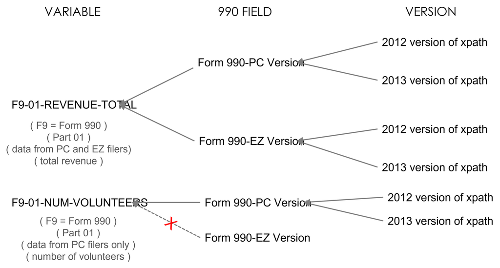

If you discover errors in the data please submit a ticket.

### Variable Names

There are over 6,500 unique variables across all 990 forms and schedules.

The variable naming convention uses the following rules:

- The prefix identifies the origin of the variable (form and part)
- Groups of variables use the NOUN-ADJECTIVE convention so that groupings are clear
  - Correct: address-street, address-city, address-state (ORG_ADDR_CITY)
  - NOT: street-address, city-address, state-address
- Variables describing check-boxes end in an _X
- All variable names are less than 32 characters in length

A table of common abbreviations used in variable names appears at the end of this document for reference.

#### Variable Prefix

The variable names have the form **XX_XX_NAME** where the first four characters represent the prefix.

The variable prefix indicates the LOCATION of the variable on the 990 forms and schedules.

**First two XX’s indicate the form**:

- F9 - Variable occurs on Form 990 or 990-EZ
- SA through SR - Variable occurs on Schedule A to Schedule R
- PF - Variable is from the 990-PF filed by private foundations
- AF - Auxillary schedule for PF filers

**The second two XX’s indicate the PART**:

Each form and schedule is sub-divided into Parts.

- 00 - Variable occurs outside of a section (“Part”) on the 990 form, typically the header
- 01 - Variable occurs in Part I of the form
- 02 - Variable occurs in Part II of the form
- Etc.

The prefix is necessary because some concepts appear frequently across several forms, for example address fields. The location prefix is included to avoid variable disambiguation problems during use.

The prefix can be easily dropped to make variable names easier to use after all required tables have been joined.

### SCOPE

The variable scope will tell you whether a particular nonprofit reported information regarding the variable depending on the version of the 990 form they used. Specifically:

- PZ - Variable relevant to BOTH full 990 and 990-EZ nonprofit filers
- PC - Variable relevant ONLY to full form 990 nonprofit filers
- EZ - Variable relevant ONLY to 990-EZ nonprofit filers

Also:

- HD - Header and signature block variables that are identical across PC, EZ, and PF forms
- PF - Variables relevant only to foundations

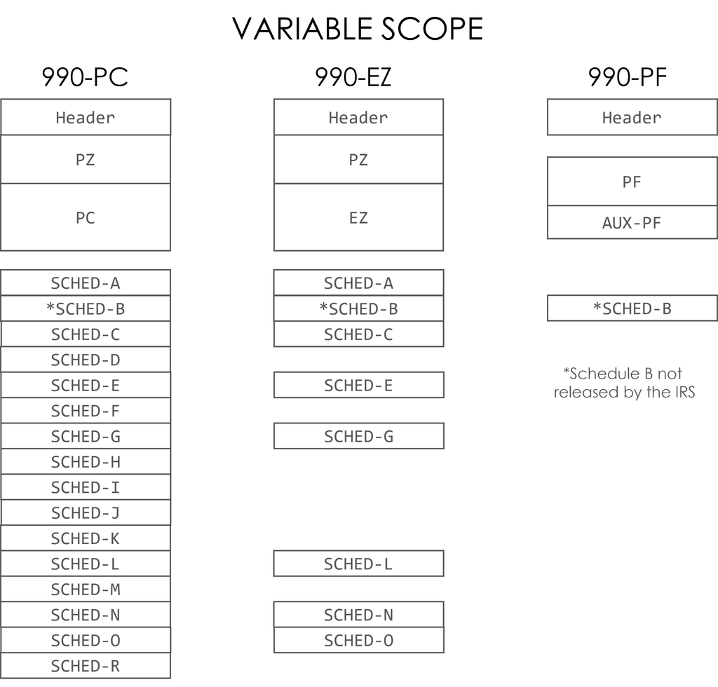

### Tables

The concordance file organizes each PART into one or more tables.

Table-00 will contain the ONE-TO-ONE variables in each PART.

Table-01, Table-02, etc. will contain the ONE-TO-MANY tables embedded in the 990 forms.

Table-99’s are supplementary tables included at the end of most forms and schedules as a place for extended explanations, comments, or attachments that don’t fit in the regular sections of the 990.

ONE-TO-ONE cardinality means each nonprofit can only provide one unique answer for the question, e.g. what is your EIN or the total revenue for the current year.

ONE-TO-MANY cardinality means that an organization can report more than one value for the question. For example, in Part VII when the nonprofit enumerates board members it will provide multiple answers for the question “board member name”.

The **URL** field that contains the HTML address of the XML form for each unique filing serves as the **unique key** for merging tables. The EIN field is the unique ID for each organization and the EIN-TaxYear pair has the potential to be a unique key combination, but if an organization has filed an amendment they EIN-TaxYear pair is not longer unique. The URL will always be unique.

### Topics

The 990 Forms and Schedules are divided into PARTS, which organize the fields by themes.

#### Form 990

- Part I - Summary
- Part II - Signature Block
- Part III - Statement of Program Service Accomplishments
- Part IV - Checklist of Required Schedules
- Part V - Statements Regarding Other IRS Filings and Tax Compliance
- Part VI - Governance, Management, and Disclosure
  - Section A. Governing Body and Management
  - Section B. Policies
  - Section C. Disclosure
- Part VII - Compensation of Officers, Directors, Trustees, Key Employees, Highest Compensated Employees, and Independent Contractors
  - Section A. Officers, Directors, Trustees, Key Employees, and Highest Compensated Employees
  - Section B. Independent Contractors
- Part VIII - Statement of Revenue
- Part IX - Statement of Functional Expenses
- Part X - Balance Sheet
- Part XI - Reconciliation of Net Assets
- Part XII - Financial Statements and Reporting

#### Schedules

- schedule a - public charity status and public support (pc and ez filers)
- schedule b - schedule of contributors (pc, ez, and pf filers)
- schedule c - political campaign and lobbying activities (pc and ez filers)
- schedule d - supplemental financial statements (pc filers only)
- schedule e - schools (pc and ez filers)
- schedule f - statement of activities outside the united states (pc filers only)
- schedule g - supplemental information regarding fundraising or gaming activities (pc and ez filers)
- schedule h - hospitals (pc filers only)
- schedule i - grants and other assistance to organizations, governments, and individuals in the united states (pc filers only)
- schedule j - compensation information (pc filers only)
- schedule k - supplemental information on tax-exempt bonds (pc filers only)
- schedule l - transactions with interested persons (pc and ez filers)
- schedule m - noncash contributions (pc filers only)
- schedule n - liquidation, termination, dissolution, or significant disposition of assets (pc and ez filers)
- schedule o - supplemental information to form 990 or 990-ez
- schedule r - related organizations and unrelated partnerships (pc filers only)

## F990 • PART-00 • TABLE-00 • HEADER

##### RDB Table Cardinality: ONE-TO-ONE

##### Table Name: F9-P00-T00-HEADER

| PREFIX | VARIABLE_NAME | DESCRIPTION | LOCATION_CODE | SCOPE |
| --- | --- | --- | --- | --- |
| F9_00_ | **BUILD_TIME_STAMP** | Build time stamp - IRS internal field | F990-PC-PART-00-LINE-00 | HD |
| F9_00_ | **NAME_ORG_CTRL** | Name of Filing Organization (Control Text) | F990-PC-PART-00-LINE-00 | HD |
| F9_00_ | **RETURN_TIME_STAMP** | The date and time when the return was created | F990-PC-PART-00-LINE-00 | HD |
| F9_00_ | **RETURN_TYPE** | Return type | F990-PC-PART-00-LINE-00 | HD |
| F9_00_ | **SPECIAL_COND_DESC** | Special condition description | F990-PC-PART-00-LINE-00; F990-EZ-PART-00-LINE-00 | HD |
| F9_00_ | **DISASTER_RELIEF** | Disaster relief text | F990-PC-PART-00-SECTION-99 | HD |
| F9_00_ | **FORM_8822B_X** | Change of address form? | F990-PC-PART-00-SECTION-99 | HD |
| F9_00_ | **IRS_RESP_PARTY_INFO_CURR_X** | Verification | F990-PC-PART-00-SECTION-99 | HD |
| F9_00_ | **IRS_SEC_DEVICE_ID** | Verification | F990-PC-PART-00-SECTION-99 | HD |
| F9_00_ | **IRS_SEC_FILING_LIC_TYPE** | Verification | F990-PC-PART-00-SECTION-99 | HD |
| F9_00_ | **IRS_SEC_IP_ADDR** | Verification | F990-PC-PART-00-SECTION-99 | HD |
| F9_00_ | **IRS_SEC_IP_DATE** | Verification | F990-PC-PART-00-SECTION-99 | HD |
| F9_00_ | **IRS_SEC_IP_TIME_ZONE** | Verification | F990-PC-PART-00-SECTION-99 | HD |
| F9_00_ | **IRS_SEC_IP_TIME** | Verification | F990-PC-PART-00-SECTION-99 | HD |
| F9_00_ | **IRS_SEC_SUBMISSION_ID** | Verification | F990-PC-PART-00-SECTION-99 | HD |
| F9_00_ | **IRS_TRUST_AUTENTICATED_X** | Verification | F990-PC-PART-00-SECTION-99 | HD |
| F9_00_ | **IRS_TRUST_CUSTOMER_X** | Verification | F990-PC-PART-00-SECTION-99 | HD |
| F9_00_ | **IRS_TRUST_FED_ASSURANCE_X** | Verification | F990-PC-PART-00-SECTION-99 | HD |
| F9_00_ | **IRS_TRUST_IDENTITY_X** | Verification | F990-PC-PART-00-SECTION-99 | HD |
| F9_00_ | **IRS_TRUST_OOB_VERIFIED_X** | Verification | F990-PC-PART-00-SECTION-99 | HD |
| F9_00_ | **IRS_TRUST_PROFILE_CHANGE_X** | Verification | F990-PC-PART-00-SECTION-99 | HD |
| F9_00_ | **IRS_TRUST_PW_CHANGE_X** | Verification | F990-PC-PART-00-SECTION-99 | HD |
| F9_00_ | **IRS_TRUST_RQR_OOB_X** | Verification | F990-PC-PART-00-SECTION-99 | HD |
| F9_00_ | **IRS_TRUST_USRNAME_CHANGE_X** | Verification | F990-PC-PART-00-SECTION-99 | HD |
| F9_00_ | **REASONABLE_CAUSE_TXT** | If the return isn’t filed by the due date (including any extension granted), provide a reasonable-cause explanation giving the reasons for not filing on time. | F990-PC-PART-00-SECTION-99 | HD |
| F9_00_ | **TAX_PERIOD_BEGIN_DATE** | Tax period begin date | F990-PC-PART-00-SECTION-A | HD |
| F9_00_ | **TAX_PERIOD_END_DATE** | Tax period end date | F990-PC-PART-00-SECTION-A | HD |
| F9_00_ | **TAX_YEAR** | Tax year | F990-PC-PART-00-SECTION-A | HD |
| F9_00_ | **ORG_NAME_CHANGE_X** | Indicates that the organization changed its name | F990-PC-PART-00-SECTION-B; F990-EZ-PART-00-SECTION-B | HD |
| F9_00_ | **RETURN_ADDR_CHANGE_X** | Indicates this form has an address change | F990-PC-PART-00-SECTION-B; F990-EZ-PART-00-SECTION-B | HD |
| F9_00_ | **RETURN_AMENDED_X** | Inidcates this form is an amended return | F990-PC-PART-00-SECTION-B; F990-EZ-PART-00-SECTION-B | HD |
| F9_00_ | **RETURN_APP_PENDING_X** | Application pending | F990-PC-PART-00-SECTION-B; F990-EZ-PART-00-SECTION-B | PZ |
| F9_00_ | **RETURN_FINAL_X** | Indicates this return is a final return | F990-PC-PART-00-SECTION-B; F990-EZ-PART-00-SECTION-B | HD |
| F9_00_ | **RETURN_INITIAL_X** | Indicates this is an initial return | F990-PC-PART-00-SECTION-B; F990-EZ-PART-00-SECTION-B | HD |
| F9_00_ | **ORG_ADDR_CITY** | Address of Filing Organization (Foreign City) | F990-PC-PART-00-SECTION-C; F990-EZ-PART-00-SECTION-C | HD |
| F9_00_ | **ORG_ADDR_CNTR** | Address of Filing Organization (Foreign Country) | F990-PC-PART-00-SECTION-C | HD |
| F9_00_ | **ORG_ADDR_IN_CARE_OF** | In care of | F990-PC-PART-00-SECTION-C | HD |
| F9_00_ | **ORG_ADDR_L1** | Address of Filing Organization (Foreign Line 1) | F990-PC-PART-00-SECTION-C; F990-EZ-PART-00-SECTION-C | HD |
| F9_00_ | **ORG_ADDR_L2** | Address of Filing Organization (Foreign Line 2) | F990-PC-PART-00-SECTION-C | HD |
| F9_00_ | **ORG_ADDR_STATE** | Address of Filing Organization (Foreign Province or State) | F990-PC-PART-00-SECTION-C; F990-EZ-PART-00-SECTION-C | HD |
| F9_00_ | **ORG_ADDR_ZIP** | Address of Filing Organization (Foreign Postal Code) | F990-PC-PART-00-SECTION-C; F990-EZ-PART-00-SECTION-C | HD |
| F9_00_ | **ORG_NAME_DBA_L1** | Doing business as (line 1) | F990-PC-PART-00-SECTION-C | HD |
| F9_00_ | **ORG_NAME_DBA_L2** | Doing business as (line 2) | F990-PC-PART-00-SECTION-C | HD |
| F9_00_ | **ORG_NAME_L1** | Name of Filing Organization (line 1) | F990-PC-PART-00-SECTION-C | HD |
| F9_00_ | **ORG_NAME_L2** | Name of Filing Organization (line 2) | F990-PC-PART-00-SECTION-C | HD |
| F9_00_ | **ORG_EIN** | Orgainization Employer Identification Number (EIN) | F990-PC-PART-00-SECTION-D | HD |
| F9_00_ | **ORG_PHONE** | Filing Organization Telephone Number | F990-PC-PART-00-SECTION-E | HD |
| F9_00_ | **PRIN_OFF_ADDR_CITY** | Address of Principal Officer (Foreign City) | F990-PC-PART-00-SECTION-F | HD |
| F9_00_ | **PRIN_OFF_ADDR_CNTR** | Address of Principal Officer (Foreign Country) | F990-PC-PART-00-SECTION-F | HD |
| F9_00_ | **PRIN_OFF_ADDR_L1** | Address of Principal Officer (Foreign Line 1) | F990-PC-PART-00-SECTION-F | HD |
| F9_00_ | **PRIN_OFF_ADDR_L2** | Address of Principal Officer (Foreign Line 2) | F990-PC-PART-00-SECTION-F | HD |
| F9_00_ | **PRIN_OFF_ADDR_STATE** | Address of Principal Officer (Foreign State) | F990-PC-PART-00-SECTION-F | HD |
| F9_00_ | **PRIN_OFF_ADDR_ZIP** | Address of Principal Officer (Foreign Postal Code) | F990-PC-PART-00-SECTION-F | HD |
| F9_00_ | **PRIN_OFF_NAME_ORG_L1** | Name Business - BusinessNameLine1 | F990-PC-PART-00-SECTION-F | HD |
| F9_00_ | **PRIN_OFF_NAME_ORG_L2** | Name of Principal Officer (Business, Line 2) | F990-PC-PART-00-SECTION-F | HD |
| F9_00_ | **PRIN_OFF_NAME_PERS** | Name Of Principal Officer - Name - Person | F990-PC-PART-00-SECTION-F | HD |
| F9_00_ | **GRO_RCPT** | Gross receipts | F990-PC-PART-00-SECTION-G; F990-EZ-PART-00-SECTION-L | HD |
| F9_00_ | **RETURN_GROUP_X** | Group return for affiliates? | F990-PC-PART-00-SECTION-HA | HD |
| F9_00_ | **ALL_AFFIL_INCL_X** | Indicates this form includes all subordinate organizations | F990-PC-PART-00-SECTION-HB | HD |
| F9_00_ | **GROUP_EXEMPT_NUM** | Group exemption number | F990-PC-PART-00-SECTION-HC; F990-EZ-PART-00-SECTION-F | HD |
| F9_00_ | **EXEMPT_STAT_4947A1_X** | Indicates a 4947(a)(1) organization | F990-PC-PART-00-SECTION-I; F990-EZ-PART-00-SECTION-J | HD |
| F9_00_ | **EXEMPT_STAT_501C_X** | Indicates a 501(c) organization | F990-PC-PART-00-SECTION-I; F990-EZ-PART-00-SECTION-J | HD |
| F9_00_ | **EXEMPT_STAT_501C3_X** | Indicates a 501(c)(3) organization | F990-PC-PART-00-SECTION-I; F990-EZ-PART-00-SECTION-J | HD |
| F9_00_ | **EXEMPT_STAT_527_X** | Indicates a 527 organization | F990-PC-PART-00-SECTION-I | HD |
| F9_00_ | **ORG_WEBSITE** | Form990 Part I - Web site | F990-PC-PART-00-SECTION-J; F990-EZ-PART-00-SECTION-I | HD |
| F9_00_ | **TYPE_ORG_ASSOC_X** | Type of organization - association | F990-PC-PART-00-SECTION-K; F990-EZ-PART-00-SECTION-K | HD |
| F9_00_ | **TYPE_ORG_CORP_X** | Type of organization - corporation | F990-PC-PART-00-SECTION-K; F990-EZ-PART-00-SECTION-K | HD |
| F9_00_ | **TYPE_ORG_OTH_DESC** | Type of organization - other description | F990-PC-PART-00-SECTION-K; F990-EZ-PART-00-SECTION-K | HD |
| F9_00_ | **TYPE_ORG_OTH_X** | Type of organization - other | F990-PC-PART-00-SECTION-K; F990-EZ-PART-00-SECTION-K | HD |
| F9_00_ | **TYPE_ORG_TRUST_X** | Type of organization - trust | F990-PC-PART-00-SECTION-K; F990-EZ-PART-00-SECTION-K | HD |
| F9_00_ | **YEAR_FORMATION** | Year of formation | F990-PC-PART-00-SECTION-L | HD |
| F9_00_ | **LEGAL_DMCL_CNTR** | Countryof legam domicile | F990-PC-PART-00-SECTION-M | HD |
| F9_00_ | **LEGAL_DMCL_STATE** | State of legal domicile | F990-PC-PART-00-SECTION-M | HD |
| F9_00_ | **GRO_RCPT_LT50K_X** | Gross receipts are less than the filing threshold ($25K or $50K depending on the year of the form) | F990-EZ-PART-00-SECTION-K | HD |

## F990 • PART-01 • TABLE-00 • SUMMARY

##### RDB Table Cardinality: ONE-TO-ONE

##### Table Name: F9-P01-T00-SUMMARY

| PREFIX | VARIABLE_NAME | DESCRIPTION | LOCATION_CODE | SCOPE |
| --- | --- | --- | --- | --- |
| F9_01_ | **ACT_GVRN_ACT_MISSION** | Organization mission or most signif activities | F990-PC-PART-01-LINE-01 | PC |
| F9_01_ | **ACT_GVRN_TERMIN_KONTR_X** | Termination or contraction | F990-PC-PART-01-LINE-02 | PC |
| F9_01_ | **ACT_GVRN_NUM_VOTE_MEMB** | Number voting members governing body | F990-PC-PART-01-LINE-03 | PC |
| F9_01_ | **ACT_GVRN_NUM_VOTE_MEMB_IND** | Number independent voting members | F990-PC-PART-01-LINE-04 | PC |
| F9_01_ | **ACT_GVRN_EMPL_TOT** | total Number employees | F990-PC-PART-01-LINE-05 | PC |
| F9_01_ | **ACT_GVRN_VOL_TOT** | Total number volunteers | F990-PC-PART-01-LINE-06 | PC |
| F9_01_ | **ACT_GVRN_UBIZ_REV_TOT** | Total gross UBI | F990-PC-PART-01-LINE-07A | PC |
| F9_01_ | **ACT_GVRN_UBIZ_TAXABLE_NET** | Net unrelated business taxable income | F990-PC-PART-01-LINE-07B | PC |
| F9_01_ | **REV_CONTR_TOT_CY** | Contributions and grants - current year | F990-PC-PART-01-LINE-08-CY; F990-EZ-PART-01-LINE-01 | PZ |
| F9_01_ | **REV_CONTR_TOT_PY** | Contributions and grants - prior year | F990-PC-PART-01-LINE-08-PY | PC |
| F9_01_ | **REV_PROG_TOT_CY** | Program service revenue - current year | F990-PC-PART-01-LINE-09-CY; F990-EZ-PART-01-LINE-02 | PZ |
| F9_01_ | **REV_PROG_TOT_PY** | Program service revenue - prior year | F990-PC-PART-01-LINE-09-PY | PC |
| F9_01_ | **REV_INVEST_TOT_CY** | Investment income - current year | F990-PC-PART-01-LINE-10-CY; F990-EZ-PART-01-LINE-04 | PZ |
| F9_01_ | **REV_INVEST_TOT_PY** | Investment income - prior year | F990-PC-PART-01-LINE-10-PY | PC |
| F9_01_ | **REV_OTH_CY** | Other revenue - current year | F990-PC-PART-01-LINE-11-CY | PZ |
| F9_01_ | **REV_OTH_PY** | Other revenue - prior year | F990-PC-PART-01-LINE-11-PY | PC |
| F9_01_ | **REV_TOT_CY** | Total revenue - CY | F990-PC-PART-01-LINE-12-CY; F990-EZ-PART-01-LINE-09 | PZ |
| F9_01_ | **REV_TOT_PY** | Total revenue - prior year | F990-PC-PART-01-LINE-12-PY | PC |
| F9_01_ | **EXP_GRANT_SIMILAR_CY** | Grants and similar amounts - CY | F990-PC-PART-01-LINE-13-CY; F990-EZ-PART-01-LINE-10 | PZ |
| F9_01_ | **EXP_GRANT_SIMILAR_PY** | Grants and similar amounts - prior year | F990-PC-PART-01-LINE-13-PY | PC |
| F9_01_ | **EXP_BEN_PAID_MEMB_CY** | Benefits paid to members - CY | F990-PC-PART-01-LINE-14-CY; F990-EZ-PART-01-LINE-11 | PZ |
| F9_01_ | **EXP_BEN_PAID_MEMB_PY** | Benefits paid to members - PY | F990-PC-PART-01-LINE-14-PY | PC |
| F9_01_ | **EXP_SAL_ETC_CY** | Salaries, etc - CY | F990-PC-PART-01-LINE-15-CY; F990-EZ-PART-01-LINE-12 | PZ |
| F9_01_ | **EXP_SAL_ETC_PY** | Salaries; etc - prior year | F990-PC-PART-01-LINE-15-PY | PC |
| F9_01_ | **EXP_PROF_FUNDR_TOT_CY** | Total professional fundraising expense - CY | F990-PC-PART-01-LINE-16A-CY | PC |
| F9_01_ | **EXP_PROF_FUNDR_TOT_PY** | Total professional fundraising expense - prior year | F990-PC-PART-01-LINE-16A-PY | PC |
| F9_01_ | **EXP_FUNDR_TOT_CY** | Total fundraising expense - CY | F990-PC-PART-01-LINE-16B | PC |
| F9_01_ | **EXP_OTH_CY** | Other expenses -CY | F990-PC-PART-01-LINE-17-CY; F990-EZ-PART-01-LINE-16 | PZ |
| F9_01_ | **EXP_OTH_PY** | Other expenses - prior year | F990-PC-PART-01-LINE-17-PY | PC |
| F9_01_ | **EXP_TOT_CY** | Total Expenses - CY | F990-PC-PART-01-LINE-18-CY; F990-EZ-PART-01-LINE-17 | PZ |
| F9_01_ | **EXP_TOT_PY** | Total Expenses - prior year | F990-PC-PART-01-LINE-18-PY | PC |
| F9_01_ | **EXP_REV_LESS_EXP_CY** | Excess or deficit - CY | F990-PC-PART-01-LINE-19-CY; F990-EZ-PART-01-LINE-18 | PZ |
| F9_01_ | **EXP_REV_LESS_EXP_PY** | Revenues less expenses - prior year | F990-PC-PART-01-LINE-19-PY | PC |
| F9_01_ | **NAFB_ASSET_TOT_BOY** | Total Assets; BOY | F990-PC-PART-01-LINE-20-BOY; F990-EZ-PART-02-LINE-25-BOY | PZ |
| F9_01_ | **NAFB_ASSET_TOT_EOY** | Total Assets; EOY | F990-PC-PART-01-LINE-20-EOY | PZ |
| F9_01_ | **NAFB_LIAB_TOT_BOY** | Total Liabilities; BOY | F990-PC-PART-01-LINE-21-BOY; F990-EZ-PART-02-LINE-26-BOY | PZ |
| F9_01_ | **NAFB_LIAB_TOT_EOY** | Total Liabilities; EOY | F990-PC-PART-01-LINE-21-EOY | PZ |
| F9_01_ | **NAFB_TOT_BOY** | Net Assets or Fund Balances; BOY | F990-PC-PART-01-LINE-22-BOY; F990-EZ-PART-01-LINE-19 | PZ |
| F9_01_ | **NAFB_TOT_EOY** | Net Assets or Fund Balances; EOY | F990-PC-PART-01-LINE-22-EOY; F990-EZ-PART-01-LINE-21 | PZ |

## F990 • PART-01 • TABLE-00 • SUMMARY-EZ

##### RDB Table Cardinality: ONE-TO-ONE

##### Table Name: F9-P01-T00-SUMMARY-EZ

| PREFIX | VARIABLE_NAME | DESCRIPTION | LOCATION_CODE | SCOPE |
| --- | --- | --- | --- | --- |
| F9_01_ | **INFO_SCHED_O_X** | Schedule O contains a response to a question in Part I | F990-EZ-PART-01-LINE-00 | EZ |
| F9_01_ | **EXP_FEE_OTH_PAY_KONTR** | Professional fees and other payments to independent contractors | F990-EZ-PART-01-LINE-13 | EZ |

## F990 • PART-02 • TABLE-00 • SIGNATURE

##### RDB Table Cardinality: ONE-TO-ONE

##### Table Name: F9-P02-T00-SIGNATURE

| PREFIX | VARIABLE_NAME | DESCRIPTION | LOCATION_CODE | SCOPE |
| --- | --- | --- | --- | --- |
| F9_02_ | **DISC_PREP_THIRD_PARTY_X** | Indicates whether IRS may discuss return with preparer | F990-PC-PART-02 | SG |
| F9_02_ | **PREP_FIRM_ADDR_CITY** | Foreign Address of Preparer Firm (City) | F990-PC-PART-02 | SG |
| F9_02_ | **PREP_FIRM_ADDR_CNTR** | Foreign Address of Preparer Firm (Country) | F990-PC-PART-02 | SG |
| F9_02_ | **PREP_FIRM_ADDR_L1** | Foreign Address of Preparer FIrm (Line 1) | F990-PC-PART-02 | SG |
| F9_02_ | **PREP_FIRM_ADDR_L2** | Foreign Address of Preparer Firm (Line 2) | F990-PC-PART-02 | SG |
| F9_02_ | **PREP_FIRM_ADDR_STATE** | Foreign Address of Preparer Firm (Province or State) | F990-PC-PART-02 | SG |
| F9_02_ | **PREP_FIRM_ADDR_ZIP** | Foreign Address of Preparer Firm (Postal Code) | F990-PC-PART-02 | SG |
| F9_02_ | **PREP_FIRM_EIN** | Employer Identification Number of Preparer Firm | F990-PC-PART-02 | SG |
| F9_02_ | **PREP_FIRM_NAME_L1** | Paid Preparer Firm Name (Line 1) | F990-PC-PART-02 | SG |
| F9_02_ | **PREP_FIRM_NAME_L2** | Paid Preparer Firm Name (Line 2) | F990-PC-PART-02 | SG |
| F9_02_ | **PREP_PERS_NAME** | Paid Preparer Name | F990-PC-PART-02 | SG |
| F9_02_ | **PREP_PERS_PHONE** | Paid Preparer Phone | F990-PC-PART-02 | SG |
| F9_02_ | **PREP_PERS_PTIN** | Paid Preparer PTIN | F990-PC-PART-02 | SG |
| F9_02_ | **PREP_PERS_SELF_EMPL_X** | Indicates that Paid Preparer is Self-Employed | F990-PC-PART-02 | SG |
| F9_02_ | **PREP_PERS_SIGNTR_DATE** | Date of Paid Preparer’s Signature | F990-PC-PART-02 | SG |
| F9_02_ | **PREP_SELF_EMPL_X** | Indicates that Paid Preparer is Self-Employed | F990-PC-PART-02 | SG |
| F9_02_ | **SIGNING_OFF_NAME_FIRST** | Signing Officer Name | F990-PC-PART-02 | SG |
| F9_02_ | **SIGNING_OFF_NAME_LAST** | Signing Officer Name | F990-PC-PART-02 | SG |
| F9_02_ | **SIGNING_OFF_NAME** | Signing Officer Name | F990-PC-PART-02 | SG |
| F9_02_ | **SIGNING_OFF_PHONE** | Signing Officer Phone Number | F990-PC-PART-02 | SG |
| F9_02_ | **SIGNING_OFF_SIGNTR_DATE** | Date of Signing Officer’s Signature | F990-PC-PART-02 | SG |
| F9_02_ | **SIGNING_OFF_SSN** | Signing officer SSN | F990-PC-PART-02 | SG |
| F9_02_ | **SIGNING_OFF_TITLE** | Signing Officer Title | F990-PC-PART-02 | SG |
| F9_02_ | **PREP_PERS_SSN** |  | F990-PC-PART-02-LINE-00 | PC |

## F990 • PART-03 • TABLE-00 • MISSION

##### RDB Table Cardinality: ONE-TO-ONE

##### Table Name: F9-P03-T00-MISSION

| PREFIX | VARIABLE_NAME | DESCRIPTION | LOCATION_CODE | SCOPE |
| --- | --- | --- | --- | --- |
| F9_03_ | **ORG_MISSION_PURPOSE** | Mission description | F990-PC-PART-03-LINE-01; F990-EZ-PART-03-LINE-00 | PZ |
| F9_03_ | **PROG_NEW_X** | Significant new program services? | F990-PC-PART-03-LINE-02 | PC |
| F9_03_ | **PROG_CHANGE_X** | Significant change? | F990-PC-PART-03-LINE-03 | PC |

## F990 • PART-03 • TABLE-00 • PROGRAM-ONE

##### RDB Table Cardinality: ONE-TO-ONE

##### Table Name: F9-P03-T00-PROGRAM-ONE

| PREFIX | VARIABLE_NAME | DESCRIPTION | LOCATION_CODE | SCOPE |
| --- | --- | --- | --- | --- |
| F9_03_ | **PROG_CODE** | IRS990 - Activity code | F990-PC-PART-03-LINE-04-ABCD | PC |
| F9_03_ | **PROG_DESC** | Program Accomplishment Description | F990-PC-PART-03-LINE-04-ABCD | PZ |
| F9_03_ | **PROG_EXP** | Program Accomplishment Expenses | F990-PC-PART-03-LINE-04-ABCD | PZ |
| F9_03_ | **PROG_GRANT** | Form990 Part III - Grants | F990-PC-PART-03-LINE-04-ABCD; F990-EZ-PART-03-LINE-28-31 | PZ |
| F9_03_ | **PROG_REV** | Form990 Part III - Revenue | F990-PC-PART-03-LINE-04-ABCD | PC |

## F990 • PART-03 • TABLE-00 • PROGRAM-THREE

##### RDB Table Cardinality: ONE-TO-ONE

##### Table Name: F9-P03-T00-PROGRAM-THREE

| PREFIX | VARIABLE_NAME | DESCRIPTION | LOCATION_CODE | SCOPE |
| --- | --- | --- | --- | --- |
| F9_03_ | **PROG_CODE** | Activity3 - Activity code | F990-PC-PART-03-LINE-04-ABCD | PC |
| F9_03_ | **PROG_DESC** | Program Accomplishment Description | F990-PC-PART-03-LINE-04-ABCD; F990-EZ-PART-03-LINE-28-31 | PZ |
| F9_03_ | **PROG_EXP** | Program Accomplishment Expenses | F990-PC-PART-03-LINE-04-ABCD | PZ |
| F9_03_ | **PROG_GRANT** | Program Accomplishment Grants | F990-PC-PART-03-LINE-04-ABCD; F990-EZ-PART-03-LINE-28-31 | PZ |
| F9_03_ | **PROG_REV** | Program Accomplishment Revenue | F990-PC-PART-03-LINE-04-ABCD | PC |

## F990 • PART-03 • TABLE-00 • PROGRAM-TWO

##### RDB Table Cardinality: ONE-TO-ONE

##### Table Name: F9-P03-T00-PROGRAM-TWO

| PREFIX | VARIABLE_NAME | DESCRIPTION | LOCATION_CODE | SCOPE |
| --- | --- | --- | --- | --- |
| F9_03_ | **PROG_CODE** | Activity2 - Activity code | F990-PC-PART-03-LINE-04-ABCD | PC |
| F9_03_ | **PROG_DESC** | Program Accomplishment Description | F990-PC-PART-03-LINE-04-ABCD; F990-EZ-PART-03-LINE-28-31 | PZ |
| F9_03_ | **PROG_EXP** | Program Accomplishment Expenses | F990-PC-PART-03-LINE-04-ABCD | PZ |
| F9_03_ | **PROG_GRANT** | Program Accomplishment Grants | F990-PC-PART-03-LINE-04-ABCD; F990-EZ-PART-03-LINE-28-31 | PZ |
| F9_03_ | **PROG_REV** | Program Accomplishment Revenue | F990-PC-PART-03-LINE-04-ABCD | PC |

## F990 • PART-03 • TABLE-00 • PROGRAMS

##### RDB Table Cardinality: ONE-TO-ONE

##### Table Name: F9-P03-T00-PROGRAMS

| PREFIX | VARIABLE_NAME | DESCRIPTION | LOCATION_CODE | SCOPE |
| --- | --- | --- | --- | --- |
| F9_03_ | **INFO_SCHED_O_X** | Was Schedule O used to respond to any part of Part III? | F990-PC-PART-03-LINE-00; F990-EZ-PART-03-LINE-00 | PZ |
| F9_03_ | **PROG_EXP_OTH_TOT** | Total of other program service expense | F990-PC-PART-03-LINE-04-ABCD | PZ |
| F9_03_ | **PROG_GRANT_OTH_TOT** | Total of other program service grants | F990-PC-PART-03-LINE-04-ABCD | PZ |
| F9_03_ | **PROG_REV_OTH_TOT** | Total of other program service revenue | F990-PC-PART-03-LINE-04-ABCD | PC |
| F9_03_ | **PROG_EXP_TOT** | Total program service expense | F990-PC-PART-03-LINE-04E; F990-EZ-PART-03-LINE-32 | PZ |

## F990 • PART-03 • TABLE-01 • PROGRAMS-OTHER

##### RDB Table Cardinality: ONE-TO-MANY

##### Table Name: F9-P03-T01-PROGRAMS-OTHER

| PREFIX | VARIABLE_NAME | DESCRIPTION | LOCATION_CODE | SCOPE |
| --- | --- | --- | --- | --- |
| F9_03_ | **PROG_CODE** | Activity Other - Activity code | F990-PC-PART-03-LINE-04-ABCD | PC |
| F9_03_ | **PROG_DESC** | Program Accomplishment Description | F990-PC-PART-03-LINE-04-ABCD; F990-EZ-PART-03-LINE-28-31 | PZ |
| F9_03_ | **PROG_EXP** | Program Accomplishment Expenses | F990-PC-PART-03-LINE-04-ABCD | PZ |
| F9_03_ | **PROG_GRANT** | Program Accomplishment Grants | F990-PC-PART-03-LINE-04-ABCD; F990-EZ-PART-03-LINE-28-31 | PZ |
| F9_03_ | **PROG_REV** | Program Accomplishment Revenue | F990-PC-PART-03-LINE-04-ABCD | PC |

## F990 • PART-03 • TABLE-02 • PROGRAMS-EZ

##### RDB Table Cardinality: ONE-TO-MANY

##### Table Name: F9-P03-T02-PROGRAMS-EZ

| PREFIX | VARIABLE_NAME | DESCRIPTION | LOCATION_CODE | SCOPE |
| --- | --- | --- | --- | --- |
| F9_03_ | **PROG_DESC** | Program Accomplishment Description | F990-EZ-PART-03-LINE-28-31 | PZ |
| F9_03_ | **PROG_GRANT_FRGN_X** | Were any foreign grants included for this program | F990-EZ-PART-03-LINE-28-31 | EZ |
| F9_03_ | **PROG_GRANT** | Program Accomplishment Grants | F990-EZ-PART-03-LINE-28-31 | PZ |
| F9_03_ | **PROG_EXP** | Program Accomplishment Expenses | F990-EZ-PART-03-LINE-28A-31A | PZ |

## F990 • PART-04 • TABLE-00 • REQUIRED-SCHEDULES

##### RDB Table Cardinality: ONE-TO-ONE

##### Table Name: F9-P04-T00-REQUIRED-SCHEDULES

| PREFIX | VARIABLE_NAME | DESCRIPTION | LOCATION_CODE | SCOPE |
| --- | --- | --- | --- | --- |
| F9_04_ | **DESC_IN_501C3_X** | Described in 501(c)(3)? | F990-PC-PART-04-LINE-01 | PC |
| F9_04_ | **SCHED_B_REQ_X** | Schedule B required? | F990-PC-PART-04-LINE-02; F990-EZ-PART-00-SECTION-H | PZ |
| F9_04_ | **POLI_ACT_X** | Political activities? | F990-PC-PART-04-LINE-03; F990-EZ-PART-05-LINE-46 | PZ |
| F9_04_ | **LOB_ACT_X** | Lobbying activities? | F990-PC-PART-04-LINE-04; F990-EZ-PART-06-LINE-47 | PZ |
| F9_04_ | **PROXY_TAX_X** | Subject to proxy tax? | F990-PC-PART-04-LINE-05; F990-EZ-PART-05-LINE-35C | PZ |
| F9_04_ | **DAF_X** | Donor advised funds? | F990-PC-PART-04-LINE-06; F990-EZ-PART-05-LINE-44A | PZ |
| F9_04_ | **CONSERV_EMT_X** | Conservation easements? | F990-PC-PART-04-LINE-07 | PC |
| F9_04_ | **COLLEC_ART_X** | Collections of art? | F990-PC-PART-04-LINE-08 | PC |
| F9_04_ | **CREDIT_COUNS_X** | Credit counseling? | F990-PC-PART-04-LINE-09 | PC |
| F9_04_ | **ENDOW_X** | Term or permanent endowments? | F990-PC-PART-04-LINE-10 | PC |
| F9_04_ | **REP_BALANCE_SHEET_AMT_X** | Balance sheet amounts reported? | F990-PC-PART-04-LINE-11 | PC |
| F9_04_ | **REP_LAND_BLDG_EQUIP_X** | Balance sheet land; buildings; equipment amounts reported? | F990-PC-PART-04-LINE-11A | PC |
| F9_04_ | **REP_INVEST_OTH_SEC_X** | Balance sheet investments - other securities amounts reported? | F990-PC-PART-04-LINE-11B | PC |
| F9_04_ | **REP_PROG_RLTD_X** | Balance sheet investments - program related amounts reported? | F990-PC-PART-04-LINE-11C | PC |
| F9_04_ | **REP_OTH_ASSET_X** | Balance sheet other assets amounts reported? | F990-PC-PART-04-LINE-11D | PC |
| F9_04_ | **REP_OTH_LIAB_X** | Balance sheet other liabilities amounts reported? | F990-PC-PART-04-LINE-11E | PC |
| F9_04_ | **REP_FOOTNOTE_FIN48_X** | Balance sheet footnote for liability under FIN 48? | F990-PC-PART-04-LINE-11F | PC |
| F9_04_ | **AFS_IND_X** | Independent audited financial statements? | F990-PC-PART-04-LINE-12A | PC |
| F9_04_ | **AFS_CONSOL_X** | Consolidated audited financial statement? | F990-PC-PART-04-LINE-12B | PC |
| F9_04_ | **SCHOOL_X** | IRS990 - School? | F990-PC-PART-04-LINE-13; F990-EZ-PART-06-LINE-48 | PZ |
| F9_04_ | **FRGN_OFFICE_X** | At any time during the calender year; did the organization maintain an office outside of the U.S.? | F990-PC-PART-04-LINE-14A; F990-EZ-PART-05-LINE-42C | PZ |
| F9_04_ | **FRGN_ACT_X** | Foreign activities; etc? | F990-PC-PART-04-LINE-14B | PC |
| F9_04_ | **GRANT_MT_5K_FRGN_ORG_X** | More than $5000 to organizations Part IX; line 3? | F990-PC-PART-04-LINE-15 | PC |
| F9_04_ | **GRANT_MT_5K_FRGN_INDIV_X** | More than $5000 to individuals Part IX; line 3? | F990-PC-PART-04-LINE-16 | PC |
| F9_04_ | **PROF_FUNDR_X** | Professional fundraising? | F990-PC-PART-04-LINE-17 | PC |
| F9_04_ | **FUNDR_ACT_X** | Fundraising activities? | F990-PC-PART-04-LINE-18 | PC |
| F9_04_ | **GAMING_X** | Form990 Part IV - Gaming? | F990-PC-PART-04-LINE-19; F990-EZ-PART-01-LINE-06 | PZ |
| F9_04_ | **HOSPITAL_X** | Form990 Part IV - Hospital? | F990-PC-PART-04-LINE-20A; F990-EZ-PART-05-LINE-44B | PC |
| F9_04_ | **HOSPITAL_AFS_X** | Audited financial statements? | F990-PC-PART-04-LINE-20B | PC |
| F9_04_ | **GRANT_MT_5K_US_ORG_X** | Grants to organizations? | F990-PC-PART-04-LINE-21 | PC |
| F9_04_ | **GRANT_MT_5K_US_INDIV_X** | Grants to individuals? | F990-PC-PART-04-LINE-22 | PC |
| F9_04_ | **COMP_DTK_YES_X** | PartVII; Lines 3; 4; or 5 = “Yes”? | F990-PC-PART-04-LINE-23 | PC |
| F9_04_ | **TAX_EXEMPT_BOND_X** | Tax exempt bonds? | F990-PC-PART-04-LINE-24A | PC |
| F9_04_ | **TAX_EXEMPT_BOND_INVEST_X** | Investment income? | F990-PC-PART-04-LINE-24B | PC |
| F9_04_ | **TAX_EXEMPT_BOND_ISSUER_X** | On behalf of issuer? | F990-PC-PART-04-LINE-24D; F990-PC-PART-04-LINE-24B | PC |
| F9_04_ | **TAX_EXEMPT_BOND_ESCROW_X** | Did the organization maintain an escrow account other than a refunding escrow at any time during the year to defease any tax-exempt bonds? | F990-PC-PART-04-LINE-24C | PC |
| F9_04_ | **TRANSAC_ENGAGED_X** | 501(c)(3) and 501(c)(4) orgs: Did the organization engage in any section 4958 excess benefit transaction | F990-PC-PART-04-LINE-25A; F990-EZ-PART-05-LINE-40B | PZ |
| F9_04_ | **TRANSAC_PY_X** | Prior excess benefit transaction? | F990-PC-PART-04-LINE-25B | PZ |
| F9_04_ | **LOAN_DTK_X** | Loan to officer or DQP? | F990-PC-PART-04-LINE-26; F990-EZ-PART-05-LINE-38A | PZ |
| F9_04_ | **GRANT_RLTD_PERS_X** | Grant to related person? | F990-PC-PART-04-LINE-27 | PC |
| F9_04_ | **BIZ_TRANSAC_DTK_X** | Was the organization a party to a business transaction with one of the following parties: A current former officer, director, trustee, or key employee? | F990-PC-PART-04-LINE-28A | PC |
| F9_04_ | **BIZ_TRANSAC_DTK_FAM_X** | Was the organization a party to a business transaction with one of the following parties: A family member of a current or former officer, director, trustee, or key employee? | F990-PC-PART-04-LINE-28B | PC |
| F9_04_ | **BIZ_TRANSAC_DTK_ENTITY_X** | A 35% controlled entity of one or more individuals and/or organizations described in line 28a or 28b? If Yes, complete Schedule L, Part IV | F990-PC-PART-04-LINE-28C | PC |
| F9_04_ | **CONTR_NONCSH_MT_25K_X** | Did the organization receive more than $25,000 in non-cash contributions? | F990-PC-PART-04-LINE-29 | PC |
| F9_04_ | **CONTR_ART_HIST_X** | Did the organization receive contributions of art, historical treasures, or other similar assets, or qualified conservation contributions? | F990-PC-PART-04-LINE-30 | PC |
| F9_04_ | **LTD_X** | Form990 Part IV - Terminated? (F990-PC-PART-04-LINE-31-32-COMBINED: F990-EZ-PART-05-LINE-36) | F990-PC-PART-04-LINE-31 | PZ |
| F9_04_ | **DOA_X** | Partial liquidation? (F990-PC-PART-04-LINE-31-32-COMBINED: F990-EZ-PART-05-LINE-36) | F990-PC-PART-04-LINE-32 | PZ |
| F9_04_ | **ENTITY_DISREG_X** | Did the organization own 100% of an entity disregarded as sperate from the organization under Regulations sections 301.7701.2 and 301.7701-3? | F990-PC-PART-04-LINE-33 | PC |
| F9_04_ | **ENTITY_RLTD_X** | Related entity? | F990-PC-PART-04-LINE-34 | PC |
| F9_04_ | **ENTITY_CTRL_X** | Did the organization have a controlled entity within the meaning of section 512(b)(13)? | F990-PC-PART-04-LINE-35A; F990-EZ-PART-05-LINE-45A | PZ |
| F9_04_ | **ENTITY_CTRL_TRANSAC_X** | Did the organization have a controlled entity within the meaning of section 512(b)(13)? | F990-PC-PART-04-LINE-35B; F990-EZ-PART-05-LINE-45B | PZ |
| F9_04_ | **TRANSFER_EXEMPT_ORG_X** | Any transfers to exempt non-charitable org? | F990-PC-PART-04-LINE-36; F990-EZ-PART-06-LINE-49A | PZ |
| F9_04_ | **PTR_ACT_X** | Did the organization conduct more than 5% of its activities through an entity that is not a related organization and thatis treated as a partnership for federal income tax purposes? | F990-PC-PART-04-LINE-37 | PC |
| F9_04_ | **SCHED_O_REQ_X** | Did the organization complete Schedule O and provide explanatios in Schedule O for Part VI, lines 11b and 19? | F990-PC-PART-04-LINE-38 | PC |
| F9_04_ | **LTD_DOA_X** | Discontinued ops or disposed 25pct assets (F990-PC-PART-04-LINE-31-32-COMBINED: F990-EZ-PART-05-LINE-36) | F990-EZ-PART-05-LINE-36 | PZ |

##### RDB Table Cardinality: ONE-TO-ONE

##### Table Name: F9-P04-T00-REQUIRED-SCHEDULES-EZ

| PREFIX | VARIABLE_NAME | DESCRIPTION | LOCATION_CODE | SCOPE |
| --- | --- | --- | --- | --- |
| F9_04_ | **LOAN_DTK_AMT** | Did the organization file Form 1120-POL for this year? | F990-EZ-PART-05-LINE-38B | EZ |
| F9_04_ | **FRGN_OFFICE_CNTR** | Name of foreign country | F990-EZ-PART-05-LINE-42C | EZ |
| F9_04_ | **RLTD_ORG_527_X** | If “Yes;” was the related organization(s) a section 527 organization? | F990-EZ-PART-06-LINE-49B | EZ |

## F990 • PART-05 • TABLE-00 • OTHER-IRS-FILING

##### RDB Table Cardinality: ONE-TO-ONE

##### Table Name: F9-P05-T00-OTHER-IRS-FILING

| PREFIX | VARIABLE_NAME | DESCRIPTION | LOCATION_CODE | SCOPE |
| --- | --- | --- | --- | --- |
| F9_05_ | **INFO_SCHED_O_X** | Does Schedule O contains a response to a question in Part V? | F990-PC-PART-05-LINE-00; F990-EZ-PART-05-LINE-00 | PZ |
| F9_05_ | **NUM_FORM_1096_BOX_3** | Number forms transmitted with 1096 | F990-PC-PART-05-LINE-01A | PC |
| F9_05_ | **NUM_FORM_W2G** | Number W-2Gs included in 1a | F990-PC-PART-05-LINE-01B | PC |
| F9_05_ | **COMPLY_BACKUP_WITHHOLD_X** | Compliance with backup witholding? | F990-PC-PART-05-LINE-01C | PC |
| F9_05_ | **NUM_EMPL** | Number of employees on Form W-3 | F990-PC-PART-05-LINE-02A | PC |
| F9_05_ | **EMPL_TAX_RETURN_FILED_X** | Employment tax returns filed? | F990-PC-PART-05-LINE-02B | PC |
| F9_05_ | **UBIZ_IMCOME_OVER_LIMIT_X** | Unrelated business income? | F990-PC-PART-05-LINE-03A; F990-EZ-PART-05-LINE-35A | PC |
| F9_05_ | **UBIZ_FORM_990T_FILED_X** | Form 990-T filed? | F990-PC-PART-05-LINE-03B; F990-EZ-PART-05-LINE-35B | PC |
| F9_05_ | **FRGN_FIN_ACC_X** | Foreign financial account? | F990-PC-PART-05-LINE-04A; F990-EZ-PART-05-LINE-42B | PZ |
| F9_05_ | **FRGN_FIN_ACC_CNTR** | Name of foreign country | F990-PC-PART-05-LINE-04B; F990-EZ-PART-05-LINE-42B | PZ |
| F9_05_ | **PTST_X** | Prohibited tax shelter transaction? | F990-PC-PART-05-LINE-05A; F990-EZ-PART-05-LINE-40E | PZ |
| F9_05_ | **PTST_PARTY_NOTIFY_X** | Taxable party notification? | F990-PC-PART-05-LINE-05B | PC |
| F9_05_ | **PTST_FORM_8886T_FILED_X** | Form 8886-T filed? | F990-PC-PART-05-LINE-05C | PC |
| F9_05_ | **NONDEDUCT_CONTR_X** | Non-deductible contributions? | F990-PC-PART-05-LINE-06A | PC |
| F9_05_ | **NONDEDUCT_CONTR_NOTIFY_X** | Non-deduct. disclosure? | F990-PC-PART-05-LINE-06B | PC |
| F9_05_ | **170C_QUID_PRO_QUO_CONTR_X** | Quid pro quo contributions? | F990-PC-PART-05-LINE-07A | PC |
| F9_05_ | **170C_QUID_PRO_QUO_NOTIFY_X** | Quid pro quo disclosure? | F990-PC-PART-05-LINE-07B | PC |
| F9_05_ | **170C_FORM_8282_REQ_X** | Form 8282 required? | F990-PC-PART-05-LINE-07C | PC |
| F9_05_ | **170C_NUM_FORM_8282_FILED_X** | Number of 8282s filed | F990-PC-PART-05-LINE-07D | PC |
| F9_05_ | **170C_FUNDS_FOR_PREMIUM_X** | Funds to pay premiums? | F990-PC-PART-05-LINE-7E; F990-PC-PART-05-LINE-07E | PC |
| F9_05_ | **170C_PREMIUM_PAID_X** | Premiums paid? | F990-PC-PART-05-LINE-07F | PC |
| F9_05_ | **170C_FORM_8899_FILED_X** | Form 8899 filed? | F990-PC-PART-05-LINE-07G | PC |
| F9_05_ | **170C_FORM_1098C_FILED_X** | Form 1098-C filed? | F990-PC-PART-05-LINE-07H | PC |
| F9_05_ | **DAF_EXCESS_BIZ_HOLDING_X** | Donor advised fund have excess business holdings? | F990-PC-PART-05-LINE-08 | PC |
| F9_05_ | **DAF_TAXABLE_DIST_X** | Taxable distributions? | F990-PC-PART-05-LINE-09A | PC |
| F9_05_ | **DAF_DIST_DONOR_X** | DAFs - Distribution to donor? | F990-PC-PART-05-LINE-09B | PC |
| F9_05_ | **501C7_INITIATION_FEES** | 501(c)(7) orgs: Initiation fees and capital contributions included on line 9 | F990-PC-PART-05-LINE-10A; F990-EZ-PART-05-LINE-39A | PZ |
| F9_05_ | **501C7_GRO_RCPT_PUB_USE** | Gross receipts amount | F990-PC-PART-05-LINE-10B; F990-EZ-PART-05-LINE-39B | PZ |
| F9_05_ | **501C12_GRO_INCOME_MEMB** | Gross income from members | F990-PC-PART-05-LINE-11A | PC |
| F9_05_ | **501C12_GRO_INCOME_OTH** | Gross income, other sources | F990-PC-PART-05-LINE-11B | PC |
| F9_05_ | **4947_FORM_990_FILED_1041_X** | Filed 990 in lieu of 1041? | F990-PC-PART-05-LINE-12A; F990-EZ-PART-05-LINE-43 | PZ |
| F9_05_ | **4947_TAX_EXEMPT_INT_AMT** | Indicates section 4947(a)(1) nonexempt charitable trusts filing Form 990 in lieu of Form 1041 | F990-PC-PART-05-LINE-12B; F990-EZ-PART-05-LINE-43 | PZ |
| F9_05_ | **501C29_LIC_HEALTH_PLAN_X** | Is the organization licensed to issue qualified health plans in more than one state? | F990-PC-PART-05-LINE-13A | PC |
| F9_05_ | **501C29_STATE_RESERVE_AMT** | State required reserves amount | F990-PC-PART-05-LINE-13B | PC |
| F9_05_ | **501C29_RESERVE_MAINT_AMT** | Reserves maintained amount | F990-PC-PART-05-LINE-13C | PC |
| F9_05_ | **TANNING_SVC_PROV_X** | Payments received for indoor tanning services? | F990-PC-PART-05-LINE-14A; F990-EZ-PART-05-LINE-44C | PZ |
| F9_05_ | **TANNING_FORM_720_FILED_X** | Form 720 filed and taxes paid on indoor tanning services? | F990-PC-PART-05-LINE-14B; F990-EZ-PART-05-LINE-44D | PZ |
| F9_05_ | **HIGH_RENUM_TAX_X** | Is the organization subject to the section 4960 tax on payment(s) of more than $1,000,000 in remuneration or excess parachute payment(s) during the year? If Yes, see the instructions and file Form 472… | F990-PC-PART-05-LINE-15 | PC |
| F9_05_ | **EXCISE_TAX_INVEST_X** | Is the organization an educational institution subject to the section 4968 excise tax on net investment income? If Yes, complete Form 4720, Schedule O. | F990-PC-PART-05-LINE-16 | PC |
| F9_05_ | **EXCISE_TAX_X** | Section 501(c)(21) organizations. Did the trust, or any disqualified or other person, engage in any activities that would result in the imposition of an excise tax under section 4951, 4952, or 4953? | F990-PC-PART-05-LINE-17 | PC |

## F990 • PART-06 • TABLE-00 • GOVERNANCE

##### RDB Table Cardinality: ONE-TO-ONE

##### Table Name: F9-P06-T00-GOVERNANCE

| PREFIX | VARIABLE_NAME | DESCRIPTION | LOCATION_CODE | SCOPE |
| --- | --- | --- | --- | --- |
| F9_06_ | **INFO_SCHED_O_X** | Schedule O contains a response to a question in Part VI | F990-PC-PART-06-LINE-00; F990-EZ-PART-05-LINE-00 | PZ |
| F9_06_ | **GVRN_NUM_VOTING_MEMB** | Number of voting governing body members | F990-PC-PART-06-SECTION-A-LINE-01A | PC |
| F9_06_ | **GVRN_NUM_VOTING_MEMB_IND** | Number of independent voting members | F990-PC-PART-06-SECTION-A-LINE-01B | PC |
| F9_06_ | **GVRN_DTK_FAMBIZ_RELATION_X** | Officer, director, trustee, or key employee has family or business relationship with other officer, directore, trustee, or key employee? | F990-PC-PART-06-SECTION-A-LINE-02 | PC |
| F9_06_ | **GVRN_DELEGATE_MGMT_DUTY_X** | Delegation of management duties? | F990-PC-PART-06-SECTION-A-LINE-03 | PC |
| F9_06_ | **GVRN_CHANGE_DOC_X** | Organization made significant changes to organizing docs since last 990? | F990-PC-PART-06-SECTION-A-LINE-04; F990-EZ-PART-05-LINE-34 | PZ |
| F9_06_ | **GVRN_ASSET_DIVERSION_X** | Material diversion or misuse? | F990-PC-PART-06-SECTION-A-LINE-05 | PC |
| F9_06_ | **GVRN_MEMB_STCKHLDR_X** | Members or stockholders? | F990-PC-PART-06-SECTION-A-LINE-06 | PC |
| F9_06_ | **GVRN_PERS_ELECT_MEMB_X** | Organization has persons who had power to elect or appoint board members? | F990-PC-PART-06-SECTION-A-LINE-07A | PC |
| F9_06_ | **GVRN_DECISION_APPROV_X** | Governance decisions subject to approval by others outside governing body? | F990-PC-PART-06-SECTION-A-LINE-07B | PC |
| F9_06_ | **GVRN_DOC_GVRN_BODY_X** | Minutes of governing body? | F990-PC-PART-06-SECTION-A-LINE-08A | PC |
| F9_06_ | **GVRN_DOC_COMMITTEE_X** | Minutes of committees? | F990-PC-PART-06-SECTION-A-LINE-08B | PC |
| F9_06_ | **GVRN_DTK_NO_MAILING_ADDR_X** | Officer mailing address? | F990-PC-PART-06-SECTION-A-LINE-09 | PC |
| F9_06_ | **POLICY_CHPTR_AFFIL_X** | Local chapters? | F990-PC-PART-06-SECTION-B-LINE-10A | PC |
| F9_06_ | **POLICY_CHPTR_REFERENCE_X** | Policies reference chapters? | F990-PC-PART-06-SECTION-B-LINE-10B | PC |
| F9_06_ | **POLICY_FORM990_GVRN_BODY_X** | Form 990 provided to governing body? | F990-PC-PART-06-SECTION-B-LINE-11A | PC |
| F9_06_ | **POLICY_COI_X** | Organization have conflict of interest policy? | F990-PC-PART-06-SECTION-B-LINE-12A | PC |
| F9_06_ | **POLICY_COI_DISCLOSURE_X** | Annual disclosure of interests by covered persons? | F990-PC-PART-06-SECTION-B-LINE-12B | PC |
| F9_06_ | **POLICY_COI_MONITOR_X** | Regular monitoring and enforcement? | F990-PC-PART-06-SECTION-B-LINE-12C | PC |
| F9_06_ | **POLICY_WHSTLBLWR_X** | Whistleblower policy? | F990-PC-PART-06-SECTION-B-LINE-13 | PC |
| F9_06_ | **POLICY_DOC_RETENTION_X** | Organization has written document retention policy? | F990-PC-PART-06-SECTION-B-LINE-14 | PC |
| F9_06_ | **POLICY_COMP_PROCESS_CEO_X** | Compensation process CEO? | F990-PC-PART-06-SECTION-B-LINE-15A | PC |
| F9_06_ | **POLICY_COMP_PROCESS_OTH_X** | Compensation process other? | F990-PC-PART-06-SECTION-B-LINE-15B | PC |
| F9_06_ | **POLICY_JV_X** | Investment in joint venture? | F990-PC-PART-06-SECTION-B-LINE-16A | PC |
| F9_06_ | **POLICY_JV_PROC_X** | Written policy or procedure? | F990-PC-PART-06-SECTION-B-LINE-16B | PC |
| F9_06_ | **DISCLOSURE_STATES_FILED** | States where return filed | F990-PC-PART-06-SECTION-C-LINE-17; F990-EZ-PART-05-LINE-41 | PZ |
| F9_06_ | **DISCLOSURE_AVBL_OTH_WEB_X** | Form990 Part VI - Other website | F990-PC-PART-06-SECTION-C-LINE-18 | PC |
| F9_06_ | **DISCLOSURE_AVBL_OTH_X** | Form available Other (explain in Schedule O) | F990-PC-PART-06-SECTION-C-LINE-18 | PC |
| F9_06_ | **DISCLOSURE_AVBL_OWN_WEB_X** | Form990 Part VI - Own website | F990-PC-PART-06-SECTION-C-LINE-18 | PC |
| F9_06_ | **DISCLOSURE_AVBL_REQUEST_X** | Form990 Part VI - Upon request | F990-PC-PART-06-SECTION-C-LINE-18 | PC |
| F9_06_ | **DISCLOSURE_BOOK_ADDR_CITY** | Person who possesses the organization’s books and records: foreign address, city | F990-PC-PART-06-SECTION-C-LINE-20; F990-EZ-PART-05-LINE-42A | PZ |
| F9_06_ | **DISCLOSURE_BOOK_ADDR_CNTR** | Person who possesses the organization’s books and records: foreign address, country | F990-PC-PART-06-SECTION-C-LINE-20; F990-EZ-PART-05-LINE-42A | PZ |
| F9_06_ | **DISCLOSURE_BOOK_ADDR_L1** | Person who possesses the organization’s books and records: foreign address, address line 1 | F990-PC-PART-06-SECTION-C-LINE-20; F990-EZ-PART-05-LINE-42A | PZ |
| F9_06_ | **DISCLOSURE_BOOK_ADDR_L2** | Person who possesses the organization’s books and records: foreign address, address line 2 | F990-PC-PART-06-SECTION-C-LINE-20; F990-EZ-PART-05-LINE-42A | PZ |
| F9_06_ | **DISCLOSURE_BOOK_ADDR_STATE** | Person who possesses the organization’s books and records: foreign address, country | F990-PC-PART-06-SECTION-C-LINE-20; F990-EZ-PART-05-LINE-42A | PZ |
| F9_06_ | **DISCLOSURE_BOOK_ADDR_ZIP** | Person who possesses the organization’s books and records: foreign address, postal code | F990-PC-PART-06-SECTION-C-LINE-20; F990-EZ-PART-05-LINE-42A | PZ |
| F9_06_ | **DISCLOSURE_BOOK_NAME_L1** | Business who possesses the organization’s books and records: name, line 1 | F990-PC-PART-06-SECTION-C-LINE-20; F990-EZ-PART-05-LINE-42A | PZ |
| F9_06_ | **DISCLOSURE_BOOK_NAME_L2** | Business who possesses the organization’s books and records: name, line 2 | F990-PC-PART-06-SECTION-C-LINE-20; F990-EZ-PART-05-LINE-42A | PZ |
| F9_06_ | **DISCLOSURE_BOOK_NAME_PERS** | Person who possesses the organization’s books and records: name | F990-PC-PART-06-SECTION-C-LINE-20; F990-EZ-PART-05-LINE-42A | PZ |
| F9_06_ | **DISCLOSURE_BOOK_PHONE** | Person who possesses the organization’s books and records: telephone number | F990-PC-PART-06-SECTION-C-LINE-20; F990-EZ-PART-05-LINE-42A | PZ |

##### RDB Table Cardinality: ONE-TO-ONE

##### Table Name: F9-P06-T00-GOVERNANCE-EZ

| PREFIX | VARIABLE_NAME | DESCRIPTION | LOCATION_CODE | SCOPE |
| --- | --- | --- | --- | --- |
| F9_06_ | **ACT_NOT_PREVIOUSLY_REP_X** | Did the organization engage in any activity not previously reported to the IRS? | F990-EZ-PART-05-LINE-33 | EZ |
| F9_06_ | **POLI_EXP** | Direct or indirect political expenditures. | F990-EZ-PART-05-LINE-37A | EZ |
| F9_06_ | **POLI_FORM1120_POL_FILED_X** | Did the organization file Form 1120-POL for this year? | F990-EZ-PART-05-LINE-37B | EZ |
| F9_06_ | **TAX_IMPOSED_IRC_4911** | 501(c)(3) Organizations: Amount of tax imposed on the organization furing the year under section 4911 | F990-EZ-PART-05-LINE-40A | EZ |
| F9_06_ | **TAX_IMPOSED_IRC_4912** | 501(c)(3) Organizations: Amount of tax imposed on the organization furing the year under section 4912 | F990-EZ-PART-05-LINE-40A | EZ |
| F9_06_ | **TAX_IMPOSED_IRC_4955** | 501(c)(3) Organizations: Amount of tax imposed on the organization furing the year under section 4955 | F990-EZ-PART-05-LINE-40A | EZ |
| F9_06_ | **TAX_IMPOSED_ORG_MGR** | Amount of tax imposed on the organization managers etc during the year under sections 4912; 4955; and 4958 | F990-EZ-PART-05-LINE-40C | EZ |
| F9_06_ | **TAX_REIMBURSED_ORG** | Amount of tax on line 89c; above; reimbursed by the organization | F990-EZ-PART-05-LINE-40D | EZ |

## F990 • PART-07 • TABLE-00 • DIR-TRUST-KEY

##### RDB Table Cardinality: ONE-TO-ONE

##### Table Name: F9-P07-T00-DIR-TRUST-KEY

| PREFIX | VARIABLE_NAME | DESCRIPTION | LOCATION_CODE | SCOPE |
| --- | --- | --- | --- | --- |
| F9_07_ | **INFO_SCHED_O_X** | Schedule O contains a response to a question in Part VII | F990-PC-PART-07-LINE-00; F990-EZ-PART-04-LINE-00 | PZ |
| F9_07_ | **COMP_DTK_NO_LISTED_X** | No listed persons compensated (F990-PC-PART-07-SECTION-A: F990-EZ-PART-04-PART-06-LINE-50-CONBINED) | F990-PC-PART-07-SECTION-A-LINE-01A | PC |
| F9_07_ | **COMP_DTK_COMP_ORG_SUBTOT** | Total; column D (F990-PC-PART-07-SECTION-A: F990-EZ-PART-04-PART-06-LINE-50-CONBINED) | F990-PC-PART-07-SECTION-A-LINE-01B-COL-D | PC |
| F9_07_ | **COMP_DTK_COMP_RLTD_SUBTOT** | Total; column E (F990-PC-PART-07-SECTION-A: F990-EZ-PART-04-PART-06-LINE-50-CONBINED) | F990-PC-PART-07-SECTION-A-LINE-01B-COL-E | PC |
| F9_07_ | **COMP_DTK_COMP_OTH_SUBTOT** | Total; column F (F990-PC-PART-07-SECTION-A: F990-EZ-PART-04-PART-06-LINE-50-CONBINED) | F990-PC-PART-07-SECTION-A-LINE-01B-COL-F | PC |
| F9_07_ | **COMP_DTK_COMP_ORG_TOT** | Total, column D (F990-PC-PART-07-SECTION-A: F990-EZ-PART-04-PART-06-LINE-50-CONBINED) | F990-PC-PART-07-SECTION-A-LINE-01D-COL-D | PC |
| F9_07_ | **COMP_DTK_COMP_RLTD_TOT** | Total, column E (F990-PC-PART-07-SECTION-A: F990-EZ-PART-04-PART-06-LINE-50-CONBINED) | F990-PC-PART-07-SECTION-A-LINE-01D-COL-E | PC |
| F9_07_ | **COMP_DTK_COMP_OTH_TOT** | Total, column F (F990-PC-PART-07-SECTION-A: F990-EZ-PART-04-PART-06-LINE-50-CONBINED) | F990-PC-PART-07-SECTION-A-LINE-01D-COL-F | PC |
| F9_07_ | **COMP_DTK_NUM_GT_100K** | Number individuals greater than $100K (F990-PC-PART-07-SECTION-A: F990-EZ-PART-04-PART-06-LINE-50-CONBINED) | F990-PC-PART-07-SECTION-A-LINE-02 | PC |
| F9_07_ | **COMP_DTK_FORMER_LISTED_X** | Is a former officer, director, or trustee listed in the compensation table in Sectin A Line 1a? (F990-PC-PART-07-SECTION-A: F990-EZ-PART-04-PART-06-LINE-50-CONBINED) | F990-PC-PART-07-SECTION-A-LINE-03 | PC |
| F9_07_ | **COMP_DTK_COMP_GT_150K_X** | Line1a; total greater than $150K? (F990-PC-PART-07-SECTION-A: F990-EZ-PART-04-PART-06-LINE-50-CONBINED) | F990-PC-PART-07-SECTION-A-LINE-04 | PC |
| F9_07_ | **COMP_DTK_COMP_OTH_SOURCE_X** | Compensation from other sources? (F990-PC-PART-07-SECTION-A: F990-EZ-PART-04-PART-06-LINE-50-CONBINED) | F990-PC-PART-07-SECTION-A-LINE-05 | PC |
| F9_07_ | **COMP_KONTR_NUM_GT_100K** | Total number of independent contractors who received 100K+ from org | F990-PC-PART-07-SECTION-B-LINE-02; F990-EZ-PART-06-LINE-51D | PZ |
| F9_07_ | **COMP_DTK_NUM_GT_100K_HCE** | Total number of other employees paid over $100;000 (F990-PC-PART-07-SECTION-A: F990-EZ-PART-04-PART-06-LINE-50-CONBINED) | F990-EZ-PART-06-LINE-50F | EZ |
| F9_07_ | **SCHED_A_FILED_X** | Did the organization complete Schedule A? | F990-EZ-PART-06-LINE-52 | EZ |

## F990 • PART-07 • TABLE-01 • COMPENSATION

##### RDB Table Cardinality: ONE-TO-MANY

##### Table Name: F9-P07-T01-COMPENSATION

| PREFIX | VARIABLE_NAME | DESCRIPTION | LOCATION_CODE | SCOPE |
| --- | --- | --- | --- | --- |
| F9_07_ | **COMP_DTK_NAME_ORG_L1** | Name Business - BusinessNameLine1 (F990-PC-PART-07-SECTION-A: F990-EZ-PART-04-PART-06-LINE-50-CONBINED) | F990-PC-PART-07-SECTION-A-LINE-01A-COL-A; F990-EZ-PART-04-COL-A | PZ |
| F9_07_ | **COMP_DTK_NAME_ORG_L2** | Name Business - BusinessNameLine2 (F990-PC-PART-07-SECTION-A: F990-EZ-PART-04-PART-06-LINE-50-CONBINED) | F990-PC-PART-07-SECTION-A-LINE-01A-COL-A; F990-EZ-PART-04-COL-A | PZ |
| F9_07_ | **COMP_DTK_NAME_PERS** | Name - Person (F990-PC-PART-07-SECTION-A: F990-EZ-PART-04-PART-06-LINE-50-CONBINED) | F990-PC-PART-07-SECTION-A-LINE-01A-COL-A; F990-EZ-PART-04-COL-A | PZ |
| F9_07_ | **COMP_DTK_TITLE** | Title (F990-PC-PART-07-SECTION-A: F990-EZ-PART-04-PART-06-LINE-50-CONBINED) | F990-PC-PART-07-SECTION-A-LINE-01A-COL-A; F990-EZ-PART-04-COL-A | PZ |
| F9_07_ | **COMP_DTK_AVE_HOUR_WEEK_RL** | Average hours per week for related organizations (F990-PC-PART-07-SECTION-A: F990-EZ-PART-04-PART-06-LINE-50-CONBINED) | F990-PC-PART-07-SECTION-A-LINE-01A-COL-B | PZ |
| F9_07_ | **COMP_DTK_AVE_HOUR_WEEK** | Average hours per week (F990-PC-PART-07-SECTION-A: F990-EZ-PART-04-PART-06-LINE-50-CONBINED) | F990-PC-PART-07-SECTION-A-LINE-01A-COL-B; F990-EZ-PART-04-COL-B | PZ |
| F9_07_ | **COMP_DTK_POS_INDIV_TRUST_X** | Individual trustee or director (F990-PC-PART-07-SECTION-A: F990-EZ-PART-04-PART-06-LINE-50-CONBINED) | F990-PC-PART-07-SECTION-A-LINE-01A-COL-C-01 | PC |
| F9_07_ | **COMP_DTK_POS_INST_TRUST_X** | Institutional Trustee (F990-PC-PART-07-SECTION-A: F990-EZ-PART-04-PART-06-LINE-50-CONBINED) | F990-PC-PART-07-SECTION-A-LINE-01A-COL-C-02 | PC |
| F9_07_ | **COMP_DTK_POS_OFF_X** | Form990 Part VIISection AGrp - Officer (F990-PC-PART-07-SECTION-A: F990-EZ-PART-04-PART-06-LINE-50-CONBINED) | F990-PC-PART-07-SECTION-A-LINE-01A-COL-C-03 | PC |
| F9_07_ | **COMP_DTK_POS_KEY_EMPL_X** | Key Employee (F990-PC-PART-07-SECTION-A: F990-EZ-PART-04-PART-06-LINE-50-CONBINED) | F990-PC-PART-07-SECTION-A-LINE-01A-COL-C-04 | PC |
| F9_07_ | **COMP_DTK_POS_HIGH_COMP_X** | Highest compensated employee (F990-PC-PART-07-SECTION-A: F990-EZ-PART-04-PART-06-LINE-50-CONBINED) | F990-PC-PART-07-SECTION-A-LINE-01A-COL-C-05 | PC |
| F9_07_ | **COMP_DTK_POS_FORMER_X** | Is a former officer, director, or trustee listed in the compensation table in Sectin A Line 1a? (F990-PC-PART-07-SECTION-A: F990-EZ-PART-04-PART-06-LINE-50-CONBINED) | F990-PC-PART-07-SECTION-A-LINE-01A-COL-C-06 | PC |
| F9_07_ | **COMP_DTK_COMP_ORG** | Reportable compensation from organization (F990-PC-PART-07-SECTION-A: F990-EZ-PART-04-PART-06-LINE-50-CONBINED) | F990-PC-PART-07-SECTION-A-LINE-01A-COL-D; F990-EZ-PART-04-COL-C | PZ |
| F9_07_ | **COMP_DTK_COMP_RLTD** | Reportable compensation from related organizations (F990-PC-PART-07-SECTION-A: F990-EZ-PART-04-PART-06-LINE-50-CONBINED) | F990-PC-PART-07-SECTION-A-LINE-01A-COL-E; F990-EZ-PART-04-COL-C | PZ |
| F9_07_ | **COMP_DTK_COMP_OTH** | Other compensation (F990-PC-PART-07-SECTION-A: F990-EZ-PART-04-PART-06-LINE-50-CONBINED) | F990-PC-PART-07-SECTION-A-LINE-01A-COL-F; F990-EZ-PART-04-COL-E | PZ |
| F9_07_ | **COMP_DTK_ADDR_CITY** | Address US - City (see F9-FORM-VERSION-2011-PART-04) | F990-EZ-PART-99-COL-A; F990-EZ-PART-04-COL-A | EZ |
| F9_07_ | **COMP_DTK_ADDR_L1** | Address US - AddressLine1 (see F9-FORM-VERSION-2011-PART-04) | F990-EZ-PART-99-COL-A; F990-EZ-PART-04-COL-A | EZ |
| F9_07_ | **COMP_DTK_ADDR_L2** | Address US - AddressLine2 (see F9-FORM-VERSION-2011-PART-04) | F990-EZ-PART-99-COL-A; F990-EZ-PART-04-COL-A | EZ |
| F9_07_ | **COMP_DTK_ADDR_STATE** | Address US - State (see F9-FORM-VERSION-2011-PART-04) | F990-EZ-PART-99-COL-A; F990-EZ-PART-04-COL-A | EZ |
| F9_07_ | **COMP_DTK_ADDR_ZIP** | Address US - ZIPCode (see F9-FORM-VERSION-2011-PART-04) | F990-EZ-PART-99-COL-A; F990-EZ-PART-04-COL-A | EZ |
| F9_07_ | **COMP_DTK_EXPL_NAME_ORG_L1** | Business Name - BusinessNameLine2 (F990-PC-PART-07-SECTION-A: F990-EZ-PART-04-PART-06-LINE-50-CONBINED) | F990-EZ-PART-04-COL-A | PZ |
| F9_07_ | **COMP_DTK_EXPL_NAME_ORG_L2** | Business Name - BusinessNameLine2 (F990-PC-PART-07-SECTION-A: F990-EZ-PART-04-PART-06-LINE-50-CONBINED) | F990-EZ-PART-04-COL-A | PZ |
| F9_07_ | **COMP_DTK_EXPL_NAME_PERS** | Name - Name - Person (F990-PC-PART-07-SECTION-A: F990-EZ-PART-04-PART-06-LINE-50-CONBINED) | F990-EZ-PART-04-COL-A | PZ |
| F9_07_ | **COMP_DTK_EXPL_TXT** | Form990 Part VIISection AGrp - Title (F990-PC-PART-07-SECTION-A: F990-EZ-PART-04-PART-06-LINE-50-CONBINED) | F990-EZ-PART-04-COL-X; F990-EZ-PART-04-COL-A | PZ |
| F9_07_ | **COMP_DTK_EMPL_BEN** | Contributions to employee benefit plans and deferred compensation (F990-PC-PART-07-SECTION-A: F990-EZ-PART-04-PART-06-LINE-50-CONBINED) | F990-EZ-PART-04-COL-D | EZ |
| F9_07_ | **COMP_DTK_ADDR_CNTR** | Address Foreign - Country (see F9-FORM-VERSION-2011-PART-04) | F990-EZ-PART-99-COL-A | PZ |

##### RDB Table Cardinality: ONE-TO-MANY

##### Table Name: F9-P07-T01-COMPENSATION-HCE-EZ

| PREFIX | VARIABLE_NAME | DESCRIPTION | LOCATION_CODE | SCOPE |
| --- | --- | --- | --- | --- |
| F9_07_ | **COMP_DTK_NONE_HCE** | If there are none; enter “None” (F990-PC-PART-07-SECTION-A: F990-EZ-PART-04-PART-06-LINE-50-CONBINED) | F990-EZ-PART-06-LINE-50 | EZ |
| F9_07_ | **COMP_DTK_NAME_PERS_HCE** | Highest paid employee’s name (F990-PC-PART-07-SECTION-A: F990-EZ-PART-04-PART-06-LINE-50-CONBINED) | F990-EZ-PART-06-LINE-50-COL-A | PZ |
| F9_07_ | **COMP_DTK_TITLE_HCE** | Compensation Highest Paid Empl Grp - Title (F990-PC-PART-07-SECTION-A: F990-EZ-PART-04-PART-06-LINE-50-CONBINED) | F990-EZ-PART-06-LINE-50-COL-A | PZ |
| F9_07_ | **COMP_DTK_AVE_HOUR_WEEK_HCE** | Average hours per week (F990-PC-PART-07-SECTION-A: F990-EZ-PART-04-PART-06-LINE-50-CONBINED) | F990-EZ-PART-06-LINE-50-COL-B | PZ |
| F9_07_ | **COMP_DTK_COMP_ORG_HCE** | Compensation Highest Paid Empl Grp - Compensation (F990-PC-PART-07-SECTION-A: F990-EZ-PART-04-PART-06-LINE-50-CONBINED) | F990-EZ-PART-06-LINE-50-COL-C | PZ |
| F9_07_ | **COMP_DTK_EMPL_BEN_HCE** | Employee benefits (F990-PC-PART-07-SECTION-A: F990-EZ-PART-04-PART-06-LINE-50-CONBINED) | F990-EZ-PART-06-LINE-50-COL-D | EZ |
| F9_07_ | **COMP_DTK_EXP_ACCT_HCE** | Expense account and other allowances | F990-EZ-PART-06-LINE-50-COL-E | EZ |
| F9_07_ | **COMP_DTK_ADDR_CITY_HCE** | Address Foreign - City (see F9-FORM-VERSION-2011-PART-06) | F990-EZ-PART-99-LINE-50-COL-A | PZ |
| F9_07_ | **COMP_DTK_ADDR_CNTR_HCE** | Address Foreign - Country (see F9-FORM-VERSION-2011-PART-06) | F990-EZ-PART-99-LINE-50-COL-A | PZ |
| F9_07_ | **COMP_DTK_ADDR_L1_HCE** | Address Foreign - AddressLine1 (see F9-FORM-VERSION-2011-PART-06) | F990-EZ-PART-99-LINE-50-COL-A | PZ |
| F9_07_ | **COMP_DTK_ADDR_L2_HCE** | Address Foreign - AddressLine2 (see F9-FORM-VERSION-2011-PART-06) | F990-EZ-PART-99-LINE-50-COL-A | PZ |
| F9_07_ | **COMP_DTK_ADDR_STATE_HCE** | Province or state (see F9-FORM-VERSION-2011-PART-06) | F990-EZ-PART-99-LINE-50-COL-A | PZ |
| F9_07_ | **COMP_DTK_ADDR_ZIP_HCE** | Address Foreign - Postal code (see F9-FORM-VERSION-2011-PART-06) | F990-EZ-PART-99-LINE-50-COL-A | PZ |

## F990 • PART-07 • TABLE-02 • CONTRACTORS

##### RDB Table Cardinality: ONE-TO-MANY

##### Table Name: F9-P07-T02-CONTRACTORS

| PREFIX | VARIABLE_NAME | DESCRIPTION | LOCATION_CODE | SCOPE |
| --- | --- | --- | --- | --- |
| F9_07_ | **COMP_KONTR_ADDR_CITY** | Highest compensated independent contractor (top 5 above 100K) foreign address city | F990-PC-PART-07-SECTION-B-LINE-01-COL-A; F990-EZ-PART-06-LINE-51-COL-A | PZ |
| F9_07_ | **COMP_KONTR_ADDR_CNTR** | Highest compensated independent contractor (top 5 above 100K) foreign address country | F990-PC-PART-07-SECTION-B-LINE-01-COL-A; F990-EZ-PART-06-LINE-51-COL-A | PZ |
| F9_07_ | **COMP_KONTR_ADDR_L1** | Highest compensated independent contractor (top 5 above 100K) foreign address line 1 | F990-PC-PART-07-SECTION-B-LINE-01-COL-A; F990-EZ-PART-06-LINE-51-COL-A | PZ |
| F9_07_ | **COMP_KONTR_ADDR_L2** | Highest compensated independent contractor (top 5 above 100K) foreign address line 2 | F990-PC-PART-07-SECTION-B-LINE-01-COL-A; F990-EZ-PART-06-LINE-51-COL-A | PZ |
| F9_07_ | **COMP_KONTR_ADDR_STATE** | Highest compensated independent contractor (top 5 above 100K) foreign address province or state | F990-PC-PART-07-SECTION-B-LINE-01-COL-A; F990-EZ-PART-06-LINE-51-COL-A | PZ |
| F9_07_ | **COMP_KONTR_ADDR_ZIP** | Highest compensated independent contractor (top 5 above 100K) foreign address zip code | F990-PC-PART-07-SECTION-B-LINE-01-COL-A; F990-EZ-PART-06-LINE-51-COL-A | PZ |
| F9_07_ | **COMP_KONTR_NAME_ORG_L1** | Highest compensated independent contractor (top 5 above 100K) business name line 1 | F990-PC-PART-07-SECTION-B-LINE-01-COL-A; F990-EZ-PART-06-LINE-51-COL-A | PZ |
| F9_07_ | **COMP_KONTR_NAME_ORG_L2** | Highest compensated independent contractor (top 5 above 100K) business name line 2 | F990-PC-PART-07-SECTION-B-LINE-01-COL-A; F990-EZ-PART-06-LINE-51-COL-A | PZ |
| F9_07_ | **COMP_KONTR_NAME_PERS** | Highest compensated independent contractor (top 5 above 100K) person name | F990-PC-PART-07-SECTION-B-LINE-01-COL-A; F990-EZ-PART-06-LINE-51-COL-A | PZ |
| F9_07_ | **COMP_KONTR_DESC_SVC** | Highest compensated independent contractor (top 5 above 100K) description of services | F990-PC-PART-07-SECTION-B-LINE-01-COL-B; F990-EZ-PART-06-LINE-51-COL-B | PZ |
| F9_07_ | **COMP_KONTR_COMP** | Highest compensated independent contractor (top 5 above 100K) compensation | F990-PC-PART-07-SECTION-B-LINE-01-COL-C; F990-EZ-PART-06-LINE-51-COL-C | PZ |
| F9_07_ | **COMP_KONTR_NONE** | If there are none; enter “None” | F990-EZ-PART-06-LINE-51-COL-A | PZ |

## F990 • PART-08 • TABLE-00 • REVENUE

##### RDB Table Cardinality: ONE-TO-ONE

##### Table Name: F9-P08-T00-REVENUE

| PREFIX | VARIABLE_NAME | DESCRIPTION | LOCATION_CODE | SCOPE |
| --- | --- | --- | --- | --- |
| F9_08_ | **INFO_SCHED_O_X** | Schedule O contains a response to a question in Part VIII | F990-PC-PART-08-LINE-00 | PC |
| F9_08_ | **REV_CONTR_FED_CAMP** | Federated campaigns | F990-PC-PART-08-LINE-01A | PC |
| F9_08_ | **REV_CONTR_MEMBSHIP_DUE** | Membership Dues | F990-PC-PART-08-LINE-01B; F990-EZ-PART-01-LINE-03 | PZ |
| F9_08_ | **REV_CONTR_FUNDR_EVNT** | Fundraising events | F990-PC-PART-08-LINE-01C | PC |
| F9_08_ | **REV_CONTR_RLTD_ORG** | Related organizations | F990-PC-PART-08-LINE-01D | PC |
| F9_08_ | **REV_CONTR_GOVT_GRANT** | Government grants (contributions) | F990-PC-PART-08-LINE-01E | PC |
| F9_08_ | **REV_CONTR_OTH** | All other contributions, gifts, grants, and similar amounts not included in above | F990-PC-PART-08-LINE-01F | PC |
| F9_08_ | **REV_CONTR_NONCSH** | Noncash contributions; attach Schedule M | F990-PC-PART-08-LINE-01G | PC |
| F9_08_ | **REV_CONTR_TOT** | Total contributions | F990-PC-PART-08-LINE-01H-COL-A | PC |
| F9_08_ | **REV_PROG_OTH_TOT** | Total Oth Program Service Revenue - Total revenue | F990-PC-PART-08-LINE-02F-COL-A | PC |
| F9_08_ | **REV_PROG_OTH_RLTD** | Related or exempt function revenue | F990-PC-PART-08-LINE-02F-COL-B | PC |
| F9_08_ | **REV_PROG_OTH_UBIZ** | Unrelated business revenue | F990-PC-PART-08-LINE-02F-COL-C | PC |
| F9_08_ | **REV_PROG_OTH_EXCL** | Excluded by section 512; 513; or 514: amount | F990-PC-PART-08-LINE-02F-COL-D | PC |
| F9_08_ | **REV_PROG_TOT_TOT** | Program service revenue total | F990-PC-PART-08-LINE-02G-COL-A | PC |
| F9_08_ | **REV_OTH_INVEST_INCOME_TOT** | Investment Income - Total revenue | F990-PC-PART-08-LINE-03-COL-A; F990-EZ-PART-01-LINE-04 | PZ |
| F9_08_ | **REV_OTH_INVEST_INCOME_RLTD** | Related or exempt function revenue | F990-PC-PART-08-LINE-03-COL-B | PC |
| F9_08_ | **REV_OTH_INVEST_INCOME_UBIZ** | Unrelated business revenue | F990-PC-PART-08-LINE-03-COL-C | PC |
| F9_08_ | **REV_OTH_INVEST_INCOME_EXCL** | Excluded by section 512; 513; or 514: amount | F990-PC-PART-08-LINE-03-COL-D | PC |
| F9_08_ | **REV_OTH_INVEST_BOND_TOT** | Income From Invest Bond Proceeds - Total revenue | F990-PC-PART-08-LINE-04-COL-A | PC |
| F9_08_ | **REV_OTH_INVEST_BOND_RLTD** | Related or exempt function revenue | F990-PC-PART-08-LINE-04-COL-B | PC |
| F9_08_ | **REV_OTH_INVEST_BOND_UBIZ** | Unrelated business revenue | F990-PC-PART-08-LINE-04-COL-C | PC |
| F9_08_ | **REV_OTH_INVEST_BOND_EXCL** | Excluded by section 512; 513; or 514: amount | F990-PC-PART-08-LINE-04-COL-D | PC |
| F9_08_ | **REV_OTH_ROY_TOT** | Royalties Revenue - Total revenue | F990-PC-PART-08-LINE-05-COL-A | PC |
| F9_08_ | **REV_OTH_ROY_RLTD** | Related or exempt function revenue | F990-PC-PART-08-LINE-05-COL-B | PC |
| F9_08_ | **REV_OTH_ROY_UBIZ** | Unrelated business revenue | F990-PC-PART-08-LINE-05-COL-C | PC |
| F9_08_ | **REV_OTH_ROY_EXCL** | Excluded by section 512; 513; or 514: amount | F990-PC-PART-08-LINE-05-COL-D | PC |
| F9_08_ | **REV_OTH_RENT_GRO_REAL** | Gross Rents - Real amount | F990-PC-PART-08-LINE-06A-COL-I | PC |
| F9_08_ | **REV_OTH_RENT_GRO_PERS** | Gross Rents - Amount | F990-PC-PART-08-LINE-06A-COL-II | PC |
| F9_08_ | **REV_OTH_RENT_LESS_EXP_REAL** | Less Rental Expenses - Real amount | F990-PC-PART-08-LINE-06B-COL-I | PC |
| F9_08_ | **REV_OTH_RENT_LESS_EXP_PERS** | Less Rental Expenses - Amount | F990-PC-PART-08-LINE-06B-COL-II | PC |
| F9_08_ | **REV_OTH_RENT_INCOME_REAL** | Rental Income Or Loss - Real amount | F990-PC-PART-08-LINE-06C-COL-I | PC |
| F9_08_ | **REV_OTH_RENT_INCOME_PERS** | Rental Income Or Loss - Amount | F990-PC-PART-08-LINE-06C-COL-II | PC |
| F9_08_ | **REV_OTH_RENT_NET_TOT** | Net Rental Income Or Loss - Total revenue | F990-PC-PART-08-LINE-06D-COL-A | PC |
| F9_08_ | **REV_OTH_RENT_NET_RLTD** | Related or exempt function revenue | F990-PC-PART-08-LINE-06D-COL-B | PC |
| F9_08_ | **REV_OTH_RENT_NET_UBIZ** | Unrelated business revenue | F990-PC-PART-08-LINE-06D-COL-C | PC |
| F9_08_ | **REV_OTH_RENT_NET_EXCL** | Excluded by section 512; 513; or 514: amount | F990-PC-PART-08-LINE-06D-COL-D | PC |
| F9_08_ | **REV_OTH_SALE_ASSET_SEC** | Securities amount | F990-PC-PART-08-LINE-07A-COL-I | PC |
| F9_08_ | **REV_OTH_SALE_ASSET_OTH** | Gross Amount Sales Assets - Other amount | F990-PC-PART-08-LINE-07A-COL-II | PZ |
| F9_08_ | **REV_OTH_SALE_LESS_COST_SEC** | Securities amount | F990-PC-PART-08-LINE-07B-COL-I | PZ |
| F9_08_ | **REV_OTH_SALE_LESS_COST_OTH** | Less Cost Oth Basis Sales Expenses - Other amount | F990-PC-PART-08-LINE-07B-COL-II | PZ |
| F9_08_ | **REV_OTH_SALE_GAIN_SEC** | Securities amount | F990-PC-PART-08-LINE-07C-COL-I | PC |
| F9_08_ | **REV_OTH_SALE_GAIN_OTH** | Gain Or Loss - Other amount | F990-PC-PART-08-LINE-07C-COL-II | PC |
| F9_08_ | **REV_OTH_SALE_GAIN_NET_TOT** | Net Gain Or Loss Investments - Total revenue | F990-PC-PART-08-LINE-07D-COL-A; F990-EZ-PART-01-LINE-05C | PZ |
| F9_08_ | **REV_OTH_SALE_GAIN_NET_RLTD** | Related or exempt function revenue | F990-PC-PART-08-LINE-07D-COL-B | PC |
| F9_08_ | **REV_OTH_SALE_GAIN_NET_UBIZ** | Unrelated business revenue | F990-PC-PART-08-LINE-07D-COL-C | PC |
| F9_08_ | **REV_OTH_SALE_GAIN_NET_EXCL** | Excluded by section 512; 513; or 514: amount | F990-PC-PART-08-LINE-07D-COL-D | PC |
| F9_08_ | **REV_OTH_FUNDR_EVNT_0** | 8a-0 | F990-PC-PART-08-LINE-08A-0 | PZ |
| F9_08_ | **REV_OTH_FUNDR_EVNT_1** | Gross income from fundraising events | F990-PC-PART-08-LINE-08A-1; F990-EZ-PART-01-LINE-06B-1 | PZ |
| F9_08_ | **REV_OTH_FUNDR_DIRECT_EXP** | Direct expenses | F990-PC-PART-08-LINE-08B | PZ |
| F9_08_ | **REV_OTH_FUNDR_NET_TOT** | Net Income From Fundraising Events - Total revenue | F990-PC-PART-08-LINE-08C-COL-A | PZ |
| F9_08_ | **REV_OTH_FUNDR_NET_RLTD** | Related or exempt function revenue | F990-PC-PART-08-LINE-08C-COL-B | PC |
| F9_08_ | **REV_OTH_FUNDR_NET_UBIZ** | Unrelated business revenue | F990-PC-PART-08-LINE-08C-COL-C | PC |
| F9_08_ | **REV_OTH_FUNDR_NET_EXCL** | Excluded by section 512; 513; or 514: amount | F990-PC-PART-08-LINE-08C-COL-D | PC |
| F9_08_ | **REV_OTH_GAMING** | Gross income from gaming | F990-PC-PART-08-LINE-09A; F990-EZ-PART-01-LINE-06A | PZ |
| F9_08_ | **REV_OTH_GAMING_DIRECT_EXP** | Direct expenses | F990-PC-PART-08-LINE-09B | PZ |
| F9_08_ | **REV_OTH_GAMING_NET_TOT** | Net Income From Gaming - Total revenue | F990-PC-PART-08-LINE-09C-COL-A | PZ |
| F9_08_ | **REV_OTH_GAMING_NET_RLTD** | Related or exempt function revenue | F990-PC-PART-08-LINE-09C-COL-B | PC |
| F9_08_ | **REV_OTH_GAMING_NET_UBIZ** | Unrelated business revenue | F990-PC-PART-08-LINE-09C-COL-C | PC |
| F9_08_ | **REV_OTH_GAMING_NET_EXCL** | Excluded by section 512; 513; or 514: amount | F990-PC-PART-08-LINE-09C-COL-D | PC |
| F9_08_ | **REV_OTH_INV_GRO_SALE** | Gross sales of inventory; less returns and allowances | F990-PC-PART-08-LINE-10A; F990-EZ-PART-01-LINE-07A | PZ |
| F9_08_ | **REV_OTH_INV_COST_GOODS** | inventory less:cost of goods sold | F990-PC-PART-08-LINE-10B; F990-EZ-PART-01-LINE-07B | PZ |
| F9_08_ | **REV_OTH_INV_NET_TOT** | Net Income Or Loss - Total revenue | F990-PC-PART-08-LINE-10C-COL-A; F990-EZ-PART-01-LINE-07C | PZ |
| F9_08_ | **REV_OTH_INV_NET_RLTD** | Related or exempt function revenue | F990-PC-PART-08-LINE-10C-COL-B | PC |
| F9_08_ | **REV_OTH_INV_NET_UBIZ** | Unrelated business revenue | F990-PC-PART-08-LINE-10C-COL-C | PC |
| F9_08_ | **REV_OTH_INV_NET_EXCL** | Excluded by section 512; 513; or 514: amount | F990-PC-PART-08-LINE-10C-COL-D | PC |
| F9_08_ | **REV_MISC_OTH_TOT** | Miscellaneous Revenue - Total revenue | F990-PC-PART-08-LINE-11D-COL-A | PC |
| F9_08_ | **REV_MISC_OTH_RLTD** | Related or exempt function revenue | F990-PC-PART-08-LINE-11D-COL-B | PC |
| F9_08_ | **REV_MISC_OTH_UBIZ** | Unrelated business revenue | F990-PC-PART-08-LINE-11D-COL-C | PC |
| F9_08_ | **REV_MISC_OTH_EXCL** | Excluded by section 512; 513; or 514: amount | F990-PC-PART-08-LINE-11D-COL-D | PC |
| F9_08_ | **REV_MISC_TOT_TOT** | Other miscellaneous revenue total | F990-PC-PART-08-LINE-11E-COL-A; F990-EZ-PART-01-LINE-08 | PZ |
| F9_08_ | **REV_TOT_TOT** | Total Revenue - Total revenue | F990-PC-PART-08-LINE-12-COL-A | PC |
| F9_08_ | **REV_TOT_RLTD** | Related or exempt function revenue | F990-PC-PART-08-LINE-12-COL-B | PC |
| F9_08_ | **REV_TOT_UBIZ** | Unrelated business revenue | F990-PC-PART-08-LINE-12-COL-C | PC |
| F9_08_ | **REV_TOT_EXCL** | Excluded by section 512; 513; or 514: amount | F990-PC-PART-08-LINE-12-COL-D | PC |
| F9_08_ | **REV_OTH_SALE_ASSET** | Gross amount from sale of assets other than inventory (F990-PC-PART-08-LINE-07A-COL-i-ii-COMBINED: F990-EZ-PART-01-LINE-05A) | F990-EZ-PART-01-LINE-05A | PZ |
| F9_08_ | **REV_OTH_SALE_LESS_COST** | Cost or other basis and sales expenses (F990-PC-PART-08-LINE-07B-COL-i-ii-COMBINED: F990-EZ-PART-01-LINE-05B) | F990-EZ-PART-01-LINE-05B | PZ |
| F9_08_ | **REV_OTH_EVNT_DIRECT_EXP** | Special events direct expenses (F990-PC-PART-08-LINE-08B-09B-COMBINED: F990-EZ-PART-01-LINE-06C) | F990-EZ-PART-01-LINE-06C | PZ |
| F9_08_ | **REV_OTH_EVNT_NET_TOT** | Special events net income (or loss) (F990-PC-PART-08-LINE-08C-09C-COL-A-COMBINED: F990-EZ-PART-01-LINE-06D) | F990-EZ-PART-01-LINE-06D | PZ |

## F990 • PART-08 • TABLE-01 • REVENUE-PROGRAMS

##### RDB Table Cardinality: ONE-TO-MANY

##### Table Name: F9-P08-T01-REVENUE-PROGRAMS

| PREFIX | VARIABLE_NAME | DESCRIPTION | LOCATION_CODE | SCOPE |
| --- | --- | --- | --- | --- |
| F9_08_ | **REV_PROG_DESC** | Program Service Revenue - Description | F990-PC-PART-08-LINE-02-ABCDE | PC |
| F9_08_ | **REV_PROG_TOT** | Program Service Revenue - Total revenue | F990-PC-PART-08-LINE-02-ABCDE-COL-A | PC |
| F9_08_ | **REV_PROG_RLTD** | Related or exempt function revenue | F990-PC-PART-08-LINE-02-ABCDE-COL-B | PC |
| F9_08_ | **REV_PROG_BIZCODE** | Program Service Revenue - Business code | F990-PC-PART-08-LINE-02-ABCDE-COL-BIZCODE | PC |
| F9_08_ | **REV_PROG_UBIZ** | Unrelated business revenue | F990-PC-PART-08-LINE-02-ABCDE-COL-C | PC |
| F9_08_ | **REV_PROG_EXCL** | Excluded by section 512; 513; or 514: amount | F990-PC-PART-08-LINE-02-ABCDE-COL-D | PC |

## F990 • PART-08 • TABLE-02 • REVENUE-MISC

##### RDB Table Cardinality: ONE-TO-MANY

##### Table Name: F9-P08-T02-REVENUE-MISC

| PREFIX | VARIABLE_NAME | DESCRIPTION | LOCATION_CODE | SCOPE |
| --- | --- | --- | --- | --- |
| F9_08_ | **REV_MISC_DESC** | Other Revenue Misc - Description | F990-PC-PART-08-LINE-11-ABC | PC |
| F9_08_ | **REV_MISC_TOT** | Other Revenue Misc - Total revenue | F990-PC-PART-08-LINE-11-ABC-COL-A | PC |
| F9_08_ | **REV_MISC_RLTD** | Related or exempt function revenue | F990-PC-PART-08-LINE-11-ABC-COL-B | PC |
| F9_08_ | **REV_MISC_BIZCODE** | Other Revenue Misc - Business code | F990-PC-PART-08-LINE-11-ABC-COL-BIZCODE | PC |
| F9_08_ | **REV_MISC_UBIZ** | Unrelated business revenue | F990-PC-PART-08-LINE-11-ABC-COL-C | PC |
| F9_08_ | **REV_MISC_EXCL** | Excluded by section 512; 513; or 514: amount | F990-PC-PART-08-LINE-11-ABC-COL-D | PC |

## F990 • PART-09 • TABLE-00 • EXPENSES

##### RDB Table Cardinality: ONE-TO-ONE

##### Table Name: F9-P09-T00-EXPENSES

| PREFIX | VARIABLE_NAME | DESCRIPTION | LOCATION_CODE | SCOPE |
| --- | --- | --- | --- | --- |
| F9_09_ | **INFO_SCHED_O_X** | Schedule O contains a response to a question in Part IX | F990-PC-PART-09-LINE-00 | PC |
| F9_09_ | **EXP_GRANT_US_ORG_TOT** | Grants To Domestic Orgs - Total | F990-PC-PART-09-LINE-01-COL-A | PZ |
| F9_09_ | **EXP_GRANT_US_ORG_PROG** | Program services | F990-PC-PART-09-LINE-01-COL-B | PC |
| F9_09_ | **EXP_GRANT_US_INDIV_TOT** | Grants To Domestic Individuals - Total | F990-PC-PART-09-LINE-02-COL-A | PC |
| F9_09_ | **EXP_GRANT_US_INDIV_PROG** | Program services | F990-PC-PART-09-LINE-02-COL-B | PC |
| F9_09_ | **EXP_GRANT_FRGN_TOT** | total Grants to Foreign Orgs and Governments - Total Expense | F990-PC-PART-09-LINE-03-COL-A | PC |
| F9_09_ | **EXP_GRANT_FRGN_PROG** | total Grants to Foreign Orgs and Governments - Program Service Expenses | F990-PC-PART-09-LINE-03-COL-B | PC |
| F9_09_ | **EXP_BEN_PAID_MEMB_TOT** | Benefits Paid to or for Members - Total Expense | F990-PC-PART-09-LINE-04-COL-A | PZ |
| F9_09_ | **EXP_BEN_PAID_MEMB_PROG** | Benefits Paid to or for Members - Program Service Expenses | F990-PC-PART-09-LINE-04-COL-B | PC |
| F9_09_ | **EXP_COMP_DTK_TOT** | Compensation for Current Officers, Directors, Trustees and Key Employees - Total Expense | F990-PC-PART-09-LINE-05-COL-A | PC |
| F9_09_ | **EXP_COMP_DTK_PROG** | Compensation for Current Officers, Directors, Trustees and Key Employees - Program | F990-PC-PART-09-LINE-05-COL-B | PC |
| F9_09_ | **EXP_COMP_DTK_MGMT** | Compensation for Current Officers, Directors, Trustees and Key Employees - Admin | F990-PC-PART-09-LINE-05-COL-C | PC |
| F9_09_ | **EXP_COMP_DTK_FUNDR** | Compensation for Current Officers, Directors, Trustees and Key Employees - Fundraising | F990-PC-PART-09-LINE-05-COL-D | PC |
| F9_09_ | **EXP_COMP_DSQ_PERS_TOT** | Compensation not included above, or to disqualified persons - Total Expense | F990-PC-PART-09-LINE-06-COL-A | PC |
| F9_09_ | **EXP_COMP_DSQ_PERS_PROG** | Compensation not included above, or to disqualified persons - Program Service Expenses | F990-PC-PART-09-LINE-06-COL-B | PC |
| F9_09_ | **EXP_COMP_DSQ_PERS_MGMT** | Compensation not included above, or to disqualified persons - Management and General | F990-PC-PART-09-LINE-06-COL-C | PC |
| F9_09_ | **EXP_COMP_DSQ_PERS_FUNDR** | Compensation not included above, or to disqualified persons - Fundraising Expenses | F990-PC-PART-09-LINE-06-COL-D | PC |
| F9_09_ | **EXP_OTH_SAL_WAGE_TOT** | Other Salaries And Wages - Total | F990-PC-PART-09-LINE-07-COL-A | PC |
| F9_09_ | **EXP_OTH_SAL_WAGE_PROG** | Program services | F990-PC-PART-09-LINE-07-COL-B | PC |
| F9_09_ | **EXP_OTH_SAL_WAGE_MGMT** | Management and general | F990-PC-PART-09-LINE-07-COL-C | PC |
| F9_09_ | **EXP_OTH_SAL_WAGE_FUNDR** | Other Salaries And Wages - Fundraising | F990-PC-PART-09-LINE-07-COL-D | PC |
| F9_09_ | **EXP_PENSION_CONTR_TOT** | Pension Plan Contributions - Total | F990-PC-PART-09-LINE-08-COL-A | PC |
| F9_09_ | **EXP_PENSION_CONTR_PROG** | Program services | F990-PC-PART-09-LINE-08-COL-B | PC |
| F9_09_ | **EXP_PENSION_CONTR_MGMT** | Management and general | F990-PC-PART-09-LINE-08-COL-C | PC |
| F9_09_ | **EXP_PENSION_CONTR_FUNDR** | Pension Plan Contributions - Fundraising | F990-PC-PART-09-LINE-08-COL-D | PC |
| F9_09_ | **EXP_OTH_EMPL_BEN_TOT** | Other Employee Benefits - Total | F990-PC-PART-09-LINE-09-COL-A | PC |
| F9_09_ | **EXP_OTH_EMPL_BEN_PROG** | Program services | F990-PC-PART-09-LINE-09-COL-B | PC |
| F9_09_ | **EXP_OTH_EMPL_BEN_MGMT** | Management and general | F990-PC-PART-09-LINE-09-COL-C | PC |
| F9_09_ | **EXP_OTH_EMPL_BEN_FUNDR** | Other Employee Benefits - Fundraising | F990-PC-PART-09-LINE-09-COL-D | PC |
| F9_09_ | **EXP_PAYROLL_TAX_TOT** | Payroll Taxes - Total | F990-PC-PART-09-LINE-10-COL-A | PC |

[output cut: 92 more lines]

## F990 • PART-09 • TABLE-01 • EXPENSES-OTHER

##### RDB Table Cardinality: ONE-TO-MANY

##### Table Name: F9-P09-T01-EXPENSES-OTHER

| PREFIX | VARIABLE_NAME | DESCRIPTION | LOCATION_CODE | SCOPE |
| --- | --- | --- | --- | --- |
| F9_09_ | **EXP_OTH_DESC** | Other Expenses - Description | F990-PC-PART-09-LINE-24-ABCD | PC |
| F9_09_ | **EXP_OTH_TOT** | Other Expenses - Total | F990-PC-PART-09-LINE-24-ABCD-COL-A | PC |
| F9_09_ | **EXP_OTH_PROG** | Program services | F990-PC-PART-09-LINE-24-ABCD-COL-B | PC |
| F9_09_ | **EXP_OTH_MGMT** | Management and general | F990-PC-PART-09-LINE-24-ABCD-COL-C | PC |
| F9_09_ | **EXP_OTH_FUNDR** | Other Expenses - Fundraising | F990-PC-PART-09-LINE-24-ABCD-COL-D | PC |

## F990 • PART-10 • TABLE-00 • BALANCE-SHEET

##### RDB Table Cardinality: ONE-TO-ONE

##### Table Name: F9-P10-T00-BALANCE-SHEET

| PREFIX | VARIABLE_NAME | DESCRIPTION | LOCATION_CODE | SCOPE |
| --- | --- | --- | --- | --- |
| F9_10_ | **INFO_SCHED_O_X** | Schedule O contains a response to a question in Part X | F990-PC-PART-10-LINE-00; F990-EZ-PART-02-LINE-00 | PZ |
| F9_10_ | **ASSET_CASH_BOY** | Cash, non-interest-bearing, beginning of year | F990-PC-PART-10-LINE-01-BOY | PZ |
| F9_10_ | **ASSET_CASH_EOY** | Cash, non-interest-bearing, end of year | F990-PC-PART-10-LINE-01-EOY | PZ |
| F9_10_ | **ASSET_SAVING_BOY** | Beginnning of year | F990-PC-PART-10-LINE-02-BOY | PZ |
| F9_10_ | **ASSET_SAVING_EOY** | Ending of year | F990-PC-PART-10-LINE-02-EOY | PZ |
| F9_10_ | **ASSET_PLEDGE_NET_BOY** | Beginnning of year | F990-PC-PART-10-LINE-03-BOY | PC |
| F9_10_ | **ASSET_PLEDGE_NET_EOY** | Ending of year | F990-PC-PART-10-LINE-03-EOY | PC |
| F9_10_ | **ASSET_ACC_NET_BOY** | Net accounts receivable, beginning of year | F990-PC-PART-10-LINE-04-BOY | PC |
| F9_10_ | **ASSET_ACC_NET_EOY** | Net accounts receivable, end of year | F990-PC-PART-10-LINE-04-EOY | PC |
| F9_10_ | **ASSET_LOAN_OFF_BOY** | Beginnning of year | F990-PC-PART-10-LINE-05-BOY | PC |
| F9_10_ | **ASSET_LOAN_OFF_EOY** | Ending of year | F990-PC-PART-10-LINE-05-EOY | PC |
| F9_10_ | **ASSET_LOAN_DSQ_PERS_BOY** | Beginnning of year | F990-PC-PART-10-LINE-06-BOY | PC |
| F9_10_ | **ASSET_LOAN_DSQ_PERS_EOY** | Ending of year | F990-PC-PART-10-LINE-06-EOY | PC |
| F9_10_ | **ASSET_NOTE_LOAN_NET_BOY** | Beginnning of year | F990-PC-PART-10-LINE-07-BOY | PC |
| F9_10_ | **ASSET_NOTE_LOAN_NET_EOY** | Ending of year | F990-PC-PART-10-LINE-07-EOY | PC |
| F9_10_ | **ASSET_INV_SALE_BOY** | Beginnning of year | F990-PC-PART-10-LINE-08-BOY | PC |
| F9_10_ | **ASSET_INV_SALE_EOY** | Ending of year | F990-PC-PART-10-LINE-08-EOY | PC |
| F9_10_ | **ASSET_EXP_PREPAID_BOY** | Beginnning of year | F990-PC-PART-10-LINE-09-BOY | PC |
| F9_10_ | **ASSET_EXP_PREPAID_EOY** | Ending of year | F990-PC-PART-10-LINE-09-EOY | PC |
| F9_10_ | **ASSET_LAND_BLDG** | Land; buildings; and equipment basis | F990-PC-PART-10-LINE-10A | PC |
| F9_10_ | **ASSET_LAND_BLDG_DEPREC** | Less: accumulated depreciation | F990-PC-PART-10-LINE-10B | PC |
| F9_10_ | **ASSET_LAND_BLDG_NET_BOY** | Beginnning of year | F990-PC-PART-10-LINE-10C-BOY; F990-EZ-PART-02-LINE-23-BOY | PZ |
| F9_10_ | **ASSET_LAND_BLDG_NET_EOY** | Ending of year | F990-PC-PART-10-LINE-10C-EOY; F990-EZ-PART-02-LINE-23-EOY | PZ |
| F9_10_ | **ASSET_INVEST_SEC_BOY** | Beginnning of year | F990-PC-PART-10-LINE-11-BOY | PZ |
| F9_10_ | **ASSET_INVEST_SEC_EOY** | Ending of year | F990-PC-PART-10-LINE-11-EOY | PZ |
| F9_10_ | **ASSET_INVEST_SEC_OTH_BOY** | Beginnning of year | F990-PC-PART-10-LINE-12-BOY | PZ |
| F9_10_ | **ASSET_INVEST_SEC_OTH_EOY** | Ending of year | F990-PC-PART-10-LINE-12-EOY | PZ |
| F9_10_ | **ASSET_INVEST_PROG_RLTD_BOY** | Beginnning of year | F990-PC-PART-10-LINE-13-BOY | PZ |
| F9_10_ | **ASSET_INVEST_PROG_RLTD_EOY** | Ending of year | F990-PC-PART-10-LINE-13-EOY | PZ |
| F9_10_ | **ASSET_INTANGIBLE_BOY** | Beginnning of year | F990-PC-PART-10-LINE-14-BOY | PC |
| F9_10_ | **ASSET_INTANGIBLE_EOY** | Ending of year | F990-PC-PART-10-LINE-14-EOY | PC |
| F9_10_ | **ASSET_OTH_BOY** | Beginnning of year | F990-PC-PART-10-LINE-15-BOY; F990-EZ-PART-02-LINE-24-BOY | PZ |
| F9_10_ | **ASSET_OTH_EOY** | Ending of year | F990-PC-PART-10-LINE-15-EOY; F990-EZ-PART-02-LINE-24-EOY | PZ |
| F9_10_ | **ASSET_TOT_BOY** | Beginnning of year | F990-PC-PART-10-LINE-16-BOY; F990-EZ-PART-02-LINE-25-BOY | PZ |
| F9_10_ | **ASSET_TOT_EOY** | Ending of year | F990-PC-PART-10-LINE-16-EOY; F990-EZ-PART-02-LINE-25-EOY | PZ |
| F9_10_ | **LIAB_ACC_PAYABLE_BOY** | Accounts payable and accrued expenses, beginning of year | F990-PC-PART-10-LINE-17-BOY | PC |
| F9_10_ | **LIAB_ACC_PAYABLE_EOY** | Accounts payable and accrued expenses, end of year | F990-PC-PART-10-LINE-17-EOY | PC |
| F9_10_ | **LIAB_GRANT_PAYABLE_BOY** | Beginnning of year | F990-PC-PART-10-LINE-18-BOY | PC |
| F9_10_ | **LIAB_GRANT_PAYABLE_EOY** | Ending of year | F990-PC-PART-10-LINE-18-EOY | PC |
| F9_10_ | **LIAB_REV_DEFERRED_BOY** | Deferred revenue, beginning of year | F990-PC-PART-10-LINE-19-BOY | PC |
| F9_10_ | **LIAB_REV_DEFERRED_EOY** | Deferred revenue, end of year | F990-PC-PART-10-LINE-19-EOY | PC |
| F9_10_ | **LIAB_TAX_EXEMPT_BOND_BOY** | Beginnning of year | F990-PC-PART-10-LINE-20-BOY | PC |
| F9_10_ | **LIAB_TAX_EXEMPT_BOND_EOY** | Ending of year | F990-PC-PART-10-LINE-20-EOY | PC |
| F9_10_ | **LIAB_ESCROW_ACC_BOY** | Escrow or custodial account liability, beginning of year | F990-PC-PART-10-LINE-21-BOY | PC |
| F9_10_ | **LIAB_ESCROW_ACC_EOY** | Escrow or custodial account liability, end of year | F990-PC-PART-10-LINE-21-EOY | PC |
| F9_10_ | **LIAB_LOAN_OFF_BOY** | Beginnning of year | F990-PC-PART-10-LINE-22-BOY | PC |
| F9_10_ | **LIAB_LOAN_OFF_EOY** | Ending of year | F990-PC-PART-10-LINE-22-EOY | PC |
| F9_10_ | **LIAB_MTG_NOTE_BOY** | Beginnning of year | F990-PC-PART-10-LINE-23-BOY | PC |
| F9_10_ | **LIAB_MTG_NOTE_EOY** | Ending of year | F990-PC-PART-10-LINE-23-EOY | PC |
| F9_10_ | **LIAB_NOTE_UNSEC_BOY** | Beginnning of year | F990-PC-PART-10-LINE-24-BOY | PC |
| F9_10_ | **LIAB_NOTE_UNSEC_EOY** | Ending of year | F990-PC-PART-10-LINE-24-EOY | PC |
| F9_10_ | **LIAB_OTH_BOY** | Beginnning of year | F990-PC-PART-10-LINE-25-BOY | PC |
| F9_10_ | **LIAB_OTH_EOY** | Ending of year | F990-PC-PART-10-LINE-25-EOY | PC |
| F9_10_ | **LIAB_TOT_BOY** | Beginnning of year | F990-PC-PART-10-LINE-26-BOY; F990-EZ-PART-02-LINE-26-BOY | PZ |
| F9_10_ | **NAFB_FOLLOW_SFAS117_X** | Organization does follow SFAS 117 | F990-PC-PART-10-LINE-26-BTWN-27 | PC |
| F9_10_ | **LIAB_TOT_EOY** | Ending of year | F990-PC-PART-10-LINE-26-EOY; F990-EZ-PART-02-LINE-26-EOY | PZ |
| F9_10_ | **NAFB_UNRESTRICT_BOY** | Beginnning of year | F990-PC-PART-10-LINE-27-COL-A; F990-PC-PART-10-LINE-27-BOY | PC |
| F9_10_ | **NAFB_UNRESTRICT_EOY** | Net assets without donor restrictions End of Year | F990-PC-PART-10-LINE-27-EOY; F990-PC-PART-10-LINE-27-COL-B | PC |
| F9_10_ | **NAFB_RESTRICT_TEMP_BOY** | Beginnning of year | F990-PC-PART-10-LINE-28-BOY | PC |
| F9_10_ | **NAFB_RESTRICT_BOY** | Net assets with donor restrictions Beginning of Year | F990-PC-PART-10-LINE-28-COL-A | PC |
| F9_10_ | **NAFB_RESTRICT_EOY** | Net assets with donor restrictions Beginning of Year | F990-PC-PART-10-LINE-28-COL-B | PC |
| F9_10_ | **NAFB_RESTRICT_TEMP_EOY** | Ending of year | F990-PC-PART-10-LINE-28-EOY | PC |
| F9_10_ | **NAFB_RESTRICT_PERM_BOY** | Beginnning of year | F990-PC-PART-10-LINE-29-BOY | PC |
| F9_10_ | **NAFB_NO_FOLLOW_SFAS117_X** | Organization does not follow SFAS 117 | F990-PC-PART-10-LINE-29-BTWN-30 | PC |
| F9_10_ | **NAFB_RESTRICT_PERM_EOY** | Ending of year | F990-PC-PART-10-LINE-29-EOY | PC |
| F9_10_ | **NAFB_CAP_STCK_BOY** | Capital stock or trust principal, or current funds, beginning of year | F990-PC-PART-10-LINE-30-BOY | PC |
| F9_10_ | **NAFB_CAP_STCK_EOY** | Capital stock or trust principal, or current funds, end of year | F990-PC-PART-10-LINE-30-EOY | PC |
| F9_10_ | **NAFB_CAP_SURPLUS_BOY** | Beginnning of year | F990-PC-PART-10-LINE-31-BOY | PC |
| F9_10_ | **NAFB_CAP_SURPLUS_EOY** | Ending of year | F990-PC-PART-10-LINE-31-EOY | PC |
| F9_10_ | **NAFB_EARNING_RETAINED_BOY** | Beginnning of year | F990-PC-PART-10-LINE-32-BOY | PC |
| F9_10_ | **NAFB_EARNING_RETAINED_EOY** | Ending of year | F990-PC-PART-10-LINE-32-EOY | PC |
| F9_10_ | **NAFB_TOT_BOY** | Beginnning of year | F990-PC-PART-10-LINE-33-BOY; F990-EZ-PART-02-LINE-27-BOY | PZ |
| F9_10_ | **NAFB_TOT_EOY** | Ending of year | F990-PC-PART-10-LINE-33-EOY; F990-EZ-PART-02-LINE-27-EOY | PZ |
| F9_10_ | **NAFB_TOT_LIAB_NAFB_BOY** | Beginnning of year | F990-PC-PART-10-LINE-34-BOY | PC |
| F9_10_ | **NAFB_TOT_LIAB_NAFB_EOY** | Ending of year | F990-PC-PART-10-LINE-34-EOY | PC |
| F9_10_ | **ASSET_CASH_SAVING_BOY** | Cash, savings, and investments, beginning of year (F990-PC-PART-10-LINE-01-02-11-12-13-BOY-COMBINED: F990-EZ-PART-02-LINE-22-BOY) | F990-EZ-PART-02-LINE-22-BOY | PZ |
| F9_10_ | **ASSET_CASH_SAVING_EOY** | Cash, savings, and investments, end of year (F990-PC-PART-10-LINE-01-02-11-12-13-EOY-COMBINED: F990-EZ-PART-02-LINE-22-EOY) | F990-EZ-PART-02-LINE-22-EOY | PZ |
| F9_10_ | **ASSET_LAND_BLDG_BOY** | Net value including lands, buildings, and equipment, beginning of year | F990-EZ-PART-02-LINE-23-BOY | PZ |
| F9_10_ | **ASSET_LAND_BLDG_EOY** | Net value including lands, buildings, and equipment, end of year | F990-EZ-PART-02-LINE-23-EOY | PZ |